# Best predictors based on XGBOOST (death as a reference)

## 0. Package loading and installation

Automatically generated by Colab.

Original file is located at https://colab.research.google.com/drive/1FMHIud9Hi0rIxnMqRfRFdzBQpKEzI796

```python
# Commented out IPython magic to ensure Python compatibility.
# For Jupyter/Colab notebooks
%reset -f
import gc
gc.collect()

import numpy as np
import pandas as pd
import time

#conda install -c conda-forge \
#    numpy \
#    scipy \
#    pandas=2.2 \
#    pyarrow=15 \
#    scikit-survival \
#    spyder

# conda install -c conda-forge fastparquet
# conda install -c conda-forge xgboost
# conda install -c conda-forge pytorch cpuonly
# conda install -c pytorch pytorch cpuonly
# conda install -c conda-forge matplotlib
# conda install -c conda-forge seaborn
# conda install spyder-notebook -c spyder-ide
# conda install notebook nbformat nbconvert
# conda install -c conda-forge xlsxwriter
# conda install -c conda-forge shap

# import subprocess, sys

# subprocess.check_call([
#     sys.executable,
#     "-m",
#     "pip",
#     "install",
#     "matplotlib"
# ])

# subprocess.check_call([
#     sys.executable,
#     "-m",
#     "pip",
#     "install",
#     "seaborn"
# ])

print("numpy:", np.__version__)


from sksurv.metrics import (
    concordance_index_ipcw,
    brier_score,
    integrated_brier_score
)
from sksurv.util import Surv

#Dput
def dput_df(df, digits=6):
    data = {
        "columns": list(df.columns),
        "data": [
            [round(x, digits) if isinstance(x, (float, np.floating)) else x
             for x in row]
            for row in df.to_numpy()
        ]
    }
    print(data)


#Glimpse function
def glimpse(df, max_width=80):
    print(f"Rows: {df.shape[0]} | Columns: {df.shape[1]}")
    for col in df.columns:
        dtype = df[col].dtype
        preview = df[col].astype(str).head(5).tolist()
        preview_str = ", ".join(preview)
        if len(preview_str) > max_width:
            preview_str = preview_str[:max_width] + "..."
        print(f"{col:<30} {str(dtype):<15} {preview_str}")
#Tabyl function
def tabyl(series):
    counts = series.value_counts(dropna=False)
    props = series.value_counts(normalize=True, dropna=False)
    return pd.DataFrame({"value": counts.index,
                         "n": counts.values,
                         "percent": props.values})
#clean_names
import re

def clean_names(df):
    """
    Mimic janitor::clean_names for pandas DataFrames.
    - Lowercase
    - Replace spaces and special chars with underscores
    - Remove non-alphanumeric/underscore
    """
    new_cols = []
    for col in df.columns:
        # lowercase
        col = col.lower()
        # replace spaces and special chars with underscore
        col = re.sub(r"[^\w]+", "_", col)
        # strip leading/trailing underscores
        col = col.strip("_")
        new_cols.append(col)
    df.columns = new_cols
    return df
```

```
numpy: 2.0.1
```

## Load data

```python
from pathlib import Path

BASE_DIR = Path(
    r"G:\My Drive\Alvacast\SISTRAT 2023\data\20241015_out\pred1"
)


import pickle

with open(BASE_DIR / "imputations_list_jan26.pkl", "rb") as f:
    imputations_list_jan26 = pickle.load(f)


imputation_nodum_1 = pd.read_parquet(
    BASE_DIR / "imputation_nondum_1.parquet",
    engine="fastparquet"
)

X_reduced_imp0 = pd.read_parquet(
    BASE_DIR / "X_reduced_imp0.parquet",
    engine="fastparquet"
)

imputation_1 = pd.read_parquet(
    BASE_DIR / "imputation_1.parquet",
    engine="fastparquet"
)


# Quick check
glimpse(imputation_nodum_1)
glimpse(imputation_1)
glimpse(X_reduced_imp0)
```

```
Rows: 88504 | Columns: 41
readmit_time_from_adm_m        float64         84.93548387096774, 12.833333333333334, 13.733333333333333, 11.966666666666667, 1...
death_time_from_adm_m          float64         84.93548387096774, 87.16129032258064, 117.2258064516129, 98.93548387096774, 37.9...
adm_age_rec3                   float64         31.53, 20.61, 42.52, 60.61, 45.08
porc_pobr                      float64         0.175679117441177, 0.187835901975632, 0.130412444472313, 0.133759185671806, 0.08...
dit_m                          float64         15.967741935483872, 5.833333333333334, 0.4752688172043005, 6.966666666666667, 6....
sex_rec                        object          man, man, man, woman, man
tenure_status_household        object          stays temporarily with a relative, owner/transferred dwellings/pays dividends, s...
cohabitation                   object          alone, family of origin, with couple/children, with couple/children, family of o...
sub_dep_icd10_status           object          drug dependence, hazardous consumption, drug dependence, drug dependence, drug d...
any_violence                   object          0.No domestic violence/sex abuse, 0.No domestic violence/sex abuse, 0.No domesti...
prim_sub_freq_rec              object          2.2–6 days/wk, 3.Daily, 3.Daily, 3.Daily, 3.Daily
tr_outcome                     object          referral, dropout, adm discharge - rule violation/undet, dropout, completion
adm_motive                     object          sanitary sector, spontaneous consultation, sanitary sector, sanitary sector, spo...
first_sub_used                 object          alcohol, alcohol, alcohol, cocaine paste, alcohol
primary_sub_mod                object          alcohol, cocaine paste, cocaine paste, cocaine paste, cocaine paste
tipo_de_vivienda_rec2          object          other/unknown, formal housing, formal housing, formal housing, formal housing
national_foreign               int32           0, 0, 0, 0, 0
plan_type_corr                 object          pg-pab, pg-pab, pg-pr, m-pr, pg-pai
occupation_condition_corr24    object          unemployed, employed, employed, inactive, unemployed
marital_status_rec             object          single, single, single, married/cohabiting, single
urbanicity_cat                 object          3.Urban, 3.Urban, 3.Urban, 3.Urban, 3.Urban
ed_attainment_corr             object          2-Completed high school or less, 3-Completed primary school or less, 2-Completed...
evaluacindelprocesoteraputico  object          logro alto, logro minimo, logro minimo, logro minimo, logro alto
eva_consumo                    object          logro alto, logro minimo, logro minimo, logro intermedio, logro alto
eva_fam                        object          logro intermedio, logro minimo, logro minimo, logro intermedio, logro alto
eva_relinterp                  object          logro alto, logro minimo, logro minimo, logro intermedio, logro alto
eva_ocupacion                  object          logro alto, logro minimo, logro minimo, logro minimo, logro intermedio
eva_sm                         object          logro intermedio, logro minimo, logro minimo, logro intermedio, logro minimo
eva_fisica                     object          logro alto, logro minimo, logro intermedio, logro intermedio, logro alto
eva_transgnorma                object          logro alto, logro minimo, logro minimo, logro minimo, logro intermedio
ethnicity                      float64         0.0, 0.0, 0.0, 0.0, 0.0
dg_psiq_cie_10_instudy         bool            False, False, True, False, False
dg_psiq_cie_10_dg              bool            True, False, False, True, False
dx_f3_mood                     int32           0, 0, 0, 0, 0
dx_f6_personality              int32           0, 0, 0, 1, 0
dx_f_any_severe_mental         bool            True, False, False, False, False
any_phys_dx                    bool            False, False, False, True, False
polysubstance_strict           int32           0, 1, 1, 1, 1
readmit_event                  float64         0.0, 1.0, 1.0, 1.0, 1.0
```

[output cut: 190 more lines]

```
eva_sm_logro intermedio        bool            True, False, False, True, False
eva_sm_logro minimo            bool            False, True, True, False, True
eva_fisica_logro alto          bool            True, False, False, False, True
eva_fisica_logro intermedio    bool            False, False, True, True, False
eva_fisica_logro minimo        bool            False, True, False, False, False
eva_transgnorma_logro alto     bool            True, False, False, False, False
eva_transgnorma_logro intermedio bool            False, False, False, False, True
eva_transgnorma_logro minimo   bool            False, True, True, True, False
adm_age_cat_30-44              bool            True, False, True, False, False
adm_age_cat_45-64              bool            False, False, False, True, True
nationality_chile_other        bool            False, False, False, False, False
plan_type_corr_m-pr            bool            False, False, False, True, False
plan_type_corr_pg-pab          bool            True, True, False, False, False
plan_type_corr_pg-pai          bool            False, False, False, False, True
plan_type_corr_pg-pr           bool            False, False, True, False, False
```

```python
if isinstance(imputations_list_jan26, list) and len(imputations_list_jan26) > 0:
    print("First element type:", type(imputations_list_jan26[0]))
    if isinstance(imputations_list_jan26[0], dict):
        print("First element keys:", imputations_list_jan26[0].keys())
    elif isinstance(imputations_list_jan26[0], (pd.DataFrame, np.ndarray)):
        print("First element shape:", imputations_list_jan26[0].shape)
```

```
First element type: <class 'pandas.DataFrame'>
First element shape: (88504, 56)
```

This code block:

#### Compare databases (transformed and original)

Inspect and compare the column names of two datasets: the first imputation from imputations_list_jan26 (which likely contains dummy variables) and imputation_nodum_1 (which, as its name suggests, probably doesn't have dummy variables).

```python
# Inspect columns of the first imputation
cols_first_imp = imputations_list_jan26[0].columns.tolist()
print("First imputation columns:", cols_first_imp[:10], "... total:", len(cols_first_imp))

# Inspect columns of imputation_no_dum
cols_nodum = imputation_nodum_1.columns.tolist()
print("No-dum columns:", cols_nodum[:10], "... total:", len(cols_nodum))

# Compare overlap
common_cols = set(cols_first_imp).intersection(cols_nodum)
missing_in_imp = [c for c in cols_nodum if c not in cols_first_imp]
missing_in_nodum = [c for c in cols_first_imp if c not in cols_nodum]

print("Common columns:", len(common_cols))
print("Missing in imputations_list_jan26:", missing_in_imp)
```

```
First imputation columns: ['adm_age_rec3', 'porc_pobr', 'dit_m', 'tenure_status_household', 'prim_sub_freq_rec', 'national_foreign', 'urbanicity_cat', 'ed_attainment_corr', 'evaluacindelprocesoteraputico', 'eva_consumo'] ... total: 56
No-dum columns: ['readmit_time_from_adm_m', 'death_time_from_adm_m', 'adm_age_rec3', 'porc_pobr', 'dit_m', 'sex_rec', 'tenure_status_household', 'cohabitation', 'sub_dep_icd10_status', 'any_violence'] ... total: 41
Common columns: 24
Missing in imputations_list_jan26: ['readmit_time_from_adm_m', 'death_time_from_adm_m', 'sex_rec', 'cohabitation', 'sub_dep_icd10_status', 'any_violence', 'tr_outcome', 'adm_motive', 'first_sub_used', 'primary_sub_mod', 'tipo_de_vivienda_rec2', 'plan_type_corr', 'occupation_condition_corr24', 'marit…
```

```python
# Inspect columns of the first imputation
cols_first_imp_raw = imputation_1.columns.tolist()
print("First imputation columns:", cols_first_imp_raw[:10], "... total:", len(cols_first_imp_raw))

# Compare overlap
common_cols_raw = set(cols_first_imp_raw).intersection(cols_nodum)
missing_in_imp_raw = [c for c in cols_nodum if c not in cols_first_imp_raw]

print("Common columns:", len(common_cols_raw))
print("Missing in imputations_list_jan26:", missing_in_imp_raw)
print(common_cols_raw)
```

```
First imputation columns: ['readmit_time_from_adm_m', 'death_time_from_adm_m', 'adm_age_rec3', 'porc_pobr', 'dit_m', 'national_foreign', 'ethnicity', 'dg_psiq_cie_10_instudy', 'dg_psiq_cie_10_dg', 'dx_f3_mood'] ... total: 78
Common columns: 16
Missing in imputations_list_jan26: ['sex_rec', 'tenure_status_household', 'cohabitation', 'sub_dep_icd10_status', 'any_violence', 'prim_sub_freq_rec', 'tr_outcome', 'adm_motive', 'first_sub_used', 'primary_sub_mod', 'tipo_de_vivienda_rec2', 'plan_type_corr', 'occupation_condition_corr24', 'marital_s…
{'porc_pobr', 'dg_psiq_cie_10_dg', 'dit_m', 'death_time_from_adm_m', 'adm_age_rec3', 'dx_f3_mood', 'readmit_event', 'dx_f6_personality', 'national_foreign', 'polysubstance_strict', 'any_phys_dx', 'ethnicity', 'death_event', 'dg_psiq_cie_10_instudy', 'readmit_time_from_adm_m', 'dx_f_any_severe_mental…
```

```python
import pandas as pd

# Example: choose a combination of variables that uniquely identify rows
key_vars = ["adm_age_rec3", "porc_pobr", "dit_m"]

# Take one imputation (first element of the list) and merge with the no-dum dataset
df_imp = imputations_list_jan26[0]
df_nodum = imputation_nodum_1

merged_check = pd.merge(
    df_imp[key_vars],
    df_nodum[key_vars],
    on=key_vars,
    how="inner"
)

print(f"Merged rows: {merged_check.shape[0]}")
print("Preview of merged check:")
print(merged_check.head())

#drop merge
del merged_check
```

```
Merged rows: 88516
Preview of merged check:
   adm_age_rec3  porc_pobr      dit_m
0         31.53   0.175679  15.967742
1         20.61   0.187836   5.833333
2         42.52   0.130412   0.475269
3         60.61   0.133759   6.966667
4         45.08   0.083189   6.903226
```

```python
import pandas as pd

# Example: choose a combination of variables that uniquely identify rows
key_vars_raw = ['dit_m',
            'readmit_time_from_adm_m',
            'death_time_from_adm_m',
            'adm_age_rec3']
# Take one imputation (first element of the list) and merge with the no-dum dataset
df_raw = imputation_1

merged_check_raw = pd.merge(
    df_imp[key_vars],
    df_raw[key_vars],
    on=key_vars,
    how="inner"
)

print(f"Merged rows: {merged_check_raw.shape[0]}")
print("Preview of merged check:")
print(merged_check_raw.head())
print(f"{(merged_check_raw.shape[0] / imputation_1.shape[0] * 100):.2f}%")
#drop merge
del merged_check_raw
```

```
Merged rows: 88516
Preview of merged check:
   adm_age_rec3  porc_pobr      dit_m
0         31.53   0.175679  15.967742
1         20.61   0.187836   5.833333
2         42.52   0.130412   0.475269
3         60.61   0.133759   6.966667
4         45.08   0.083189   6.903226
100.01%
```

### Create bins for followup (landmarks)

```python
import numpy as np

# Required columns for survival outcomes
required = ["readmit_time_from_disch_m", "readmit_event",
            "death_time_from_disch_m", "death_event"]

# Check that df_raw has all required columns
missing = [c for c in required if c not in df_raw.columns]
if missing:
    raise KeyError(f"df_nodum is missing columns: {missing}")

# Create time/event arrays directly from df_raw
time_readm = df_raw["readmit_time_from_adm_m"].to_numpy()
event_readm = (df_raw["readmit_event"].to_numpy() == 1)

time_death = df_raw["death_time_from_adm_m"].to_numpy()
event_death = (df_nodum["death_event"].to_numpy() == 1)

print("Arrays created for df_raw:")
print("Readmission times:", time_readm[:5])
print("Readmission events:", event_readm[:5])
print("Death times:", time_death[:5])
print("Death events:", event_death[:5])

# Build evaluation grids (quantiles of event times)
event_times_readm = time_readm[event_readm]
event_times_death = time_death[event_death]

if len(event_times_readm) < 5 or len(event_times_death) < 5:
    raise ValueError("Too few events in df_raw to build reliable time grids.")

times_eval_readm = np.unique(np.quantile(event_times_readm, np.linspace(0.05, 0.95, 50)))
times_eval_death = np.unique(np.quantile(event_times_death, np.linspace(0.05, 0.95, 50)))

print("Eval times (readmission):", times_eval_readm[:5], "...", times_eval_readm[-5:])
print("Eval times (death):", times_eval_death[:5], "...", times_eval_death[-5:])
```

```
Arrays created for df_raw:
Readmission times: [84.93548387 12.83333333 13.73333333 11.96666667 14.25806452]
Readmission events: [False  True  True  True  True]
Death times: [ 84.93548387  87.16129032 117.22580645  98.93548387  37.93548387]
Death events: [False False False False False]
Eval times (readmission): [3.93548387 4.77419355 5.45058701 6.06492649 6.67741935] ... [54.44173469 58.41566162 63.23333333 68.54767171 74.68983871]
Eval times (death): [4.16290323 5.43022383 6.68564845 8.24254115 9.77961817] ... [81.92700461 85.41186103 88.78518762 93.5538183  99.21935484]
```

## Prepare data

First, we eliminated inmortal time bias (dead patients look like without readmission).

This correction is essentially the Cause-Specific Hazard preparation. It is the correct way to handle Aim 3 unless you switch to a Fine-Gray model (which treats death as a specific type of event 2, rather than censoring 0). For RSF/Coxnet, censoring 0 is the correct approach.

```python
import numpy as np

# Step 1. Extract survival outcomes directly from df_raw
time_readm = df_raw["readmit_time_from_adm_m"].to_numpy()
event_readm = (df_raw["readmit_event"].to_numpy() == 1)

time_death = df_raw["death_time_from_adm_m"].to_numpy()
event_death = (df_raw["death_event"].to_numpy() == 1)

# Step 2. Build structured arrays (Surv objects)
y_surv_readm = np.empty(len(time_readm), dtype=[("event", "?"), ("time", "<f8")])
y_surv_readm["event"] = event_readm
y_surv_readm["time"] = time_readm

y_surv_death = np.empty(len(time_death), dtype=[("event", "?"), ("time", "<f8")])
y_surv_death["event"] = event_death
y_surv_death["time"] = time_death

# Step 3. Replicate across imputations
n_imputations = len(imputations_list_jan26)
y_surv_readm_list = [y_surv_readm for _ in range(n_imputations)]
y_surv_death_list = [y_surv_death for _ in range(n_imputations)]

import numpy as np

def correct_competing_risks(X_list, y_readm_list, y_death_list):
    """
    Adjust survival outcomes for competing risks (death vs. readmission).

    Parameters
    ----------
    X_list : list of pd.DataFrame
        Imputed predictor datasets (same rows across imputations).
    y_readm_list : list of structured arrays
        Surv(event, time) arrays for readmission.
    y_death_list : list of structured arrays
        Surv(event, time) arrays for death.

    Returns
    -------
    y_readm_corrected_list : list of structured arrays
        Corrected readmission outcomes (death treated as censoring).
    """
    corrected = []
    for y_readm, y_death in zip(y_readm_list, y_death_list):
        y_corr = y_readm.copy()
        # If patient died before readmission → censor at death time
        for i in range(len(y_corr)):
            if y_death["event"][i] and y_death["time"][i] < y_corr["time"][i]:
                y_corr["event"][i] = False
                y_corr["time"][i] = y_death["time"][i]
        corrected.append(y_corr)
    return corrected


# Step 4. Apply correction
y_surv_readm_list_corrected = correct_competing_risks(
    imputations_list_jan26,
    y_surv_readm_list,
    y_surv_death_list
)
```

```python
# Check type and length
type(y_surv_readm_list_corrected), len(y_surv_readm_list_corrected)

# Look at the first element
y_surv_readm_list_corrected[0][:5]   # first 5 rows
```

```
array([(False, 84.93548387), ( True, 12.83333333), ( True, 13.73333333),
       ( True, 11.96666667), ( True, 14.25806452)],
      dtype=[('event', '?'), ('time', '<f8')])
```

```python
glimpse(imputations_list_jan26[0])
print(y_surv_readm_list_corrected[0].shape, y_surv_readm_list_corrected[0].dtype)
```

```
Rows: 88504 | Columns: 56
adm_age_rec3                   float64         31.53, 20.61, 42.52, 60.61, 45.08
porc_pobr                      float64         0.175679117441177, 0.187835901975632, 0.130412444472313, 0.133759185671806, 0.08...
dit_m                          float64         15.967741935483872, 5.833333333333334, 0.4752688172043005, 6.966666666666667, 6....
tenure_status_household        int64           3, 0, 3, 0, 3
prim_sub_freq_rec              int64           1, 2, 2, 2, 2
national_foreign               int32           0, 0, 0, 0, 0
urbanicity_cat                 int64           0, 0, 0, 0, 0
ed_attainment_corr             float64         1.0, 2.0, 1.0, 1.0, 2.0
evaluacindelprocesoteraputico  int64           0, 2, 2, 2, 0
eva_consumo                    int64           0, 2, 2, 1, 0
eva_fam                        int64           1, 2, 2, 1, 0
eva_relinterp                  int64           0, 2, 2, 1, 0
eva_ocupacion                  int64           0, 2, 2, 2, 1
eva_sm                         int64           1, 2, 2, 1, 2
eva_fisica                     int64           0, 2, 1, 1, 0
eva_transgnorma                int64           0, 2, 2, 2, 1
ethnicity                      float64         0.0, 0.0, 0.0, 0.0, 0.0
dg_psiq_cie_10_instudy         bool            False, False, True, False, False
dg_psiq_cie_10_dg              bool            True, False, False, True, False
dx_f3_mood                     int32           0, 0, 0, 0, 0
dx_f6_personality              int32           0, 0, 0, 1, 0
dx_f_any_severe_mental         bool            True, False, False, False, False
any_phys_dx                    bool            False, False, False, True, False
polysubstance_strict           int32           0, 1, 1, 1, 1
sex_rec_woman                  float64         0.0, 0.0, 0.0, 1.0, 0.0
cohabitation_family_of_origin  float64         0.0, 1.0, 0.0, 0.0, 1.0
cohabitation_with_couple_children float64         0.0, 0.0, 1.0, 1.0, 0.0
cohabitation_others            float64         0.0, 0.0, 0.0, 0.0, 0.0
sub_dep_icd10_status_drug_dependence float64         1.0, 0.0, 1.0, 1.0, 1.0
any_violence_1_domestic_violence_sex_abuse float64         0.0, 0.0, 0.0, 0.0, 0.0
tr_outcome_referral            float64         1.0, 0.0, 0.0, 0.0, 0.0
tr_outcome_dropout             float64         0.0, 1.0, 0.0, 1.0, 0.0
tr_outcome_adm_discharge_rule_violation_undet float64         0.0, 0.0, 1.0, 0.0, 0.0
tr_outcome_adm_discharge_adm_reasons float64         0.0, 0.0, 0.0, 0.0, 0.0
tr_outcome_other               float64         0.0, 0.0, 0.0, 0.0, 0.0
adm_motive_sanitary_sector     float64         1.0, 0.0, 1.0, 1.0, 0.0
adm_motive_another_sud_facility_fonodrogas_senda_previene float64         0.0, 0.0, 0.0, 0.0, 0.0
adm_motive_justice_sector      float64         0.0, 0.0, 0.0, 0.0, 0.0
adm_motive_other               float64         0.0, 0.0, 0.0, 0.0, 0.0
first_sub_used_alcohol         float64         1.0, 1.0, 1.0, 0.0, 1.0
first_sub_used_cocaine_paste   float64         0.0, 0.0, 0.0, 1.0, 0.0
first_sub_used_cocaine_powder  float64         0.0, 0.0, 0.0, 0.0, 0.0
primary_sub_mod_cocaine_powder float64         0.0, 0.0, 0.0, 0.0, 0.0
primary_sub_mod_alcohol        float64         1.0, 0.0, 0.0, 0.0, 0.0
primary_sub_mod_marijuana      float64         0.0, 0.0, 0.0, 0.0, 0.0
primary_sub_mod_others         float64         0.0, 0.0, 0.0, 0.0, 0.0
tipo_de_vivienda_rec2_other_unknown float64         1.0, 0.0, 0.0, 0.0, 0.0
plan_type_corr_pg_pr           float64         0.0, 0.0, 1.0, 0.0, 0.0
plan_type_corr_m_pr            float64         0.0, 0.0, 0.0, 1.0, 0.0
plan_type_corr_pg_pai          float64         0.0, 0.0, 0.0, 0.0, 1.0
plan_type_corr_m_pai           float64         0.0, 0.0, 0.0, 0.0, 0.0
occupation_condition_corr24_unemployed float64         1.0, 0.0, 0.0, 0.0, 1.0
occupation_condition_corr24_inactive float64         0.0, 0.0, 0.0, 1.0, 0.0
marital_status_rec_single      float64         1.0, 1.0, 1.0, 0.0, 1.0
marital_status_rec_separated_divorced_annulled_widowed float64         0.0, 0.0, 0.0, 0.0, 0.0
first_sub_used_other           float64         0.0, 0.0, 0.0, 0.0, 0.0
(88504,) [('event', '?'), ('time', '<f8')]
```

## ML

### Advanced Survival Modeling: XGBoost & Stratified Evaluation

In this section, we transition to a Gradient Boosted Decision Tree (GBDT) framework using XGBoost. This approach serves as a robust, non-linear benchmark to validate findings from the neural network, specifically optimized for high-imbalance survival data (approx. 4% death rate).

#### Methodological Framework:

- **Cox-Objective Boosting:** We utilize the `survival:cox` objective, which optimizes the Cox partial log-likelihood within a boosting architecture. This allows the model to learn complex non-linear risk functions and interactions without assuming proportional hazards or requiring manual interaction terms.
- **Stratified 10-Fold Cross-Validation:** To ensure robustness across diverse treatment modalities, we implement `StratifiedKFold` based on Plan Type (Outpatient, Intensive, Residential). This guarantees that every validation fold maintains the same distribution of clinical settings as the full dataset, preventing the model from overfitting to the majority treatment type.
- **Robust Metrics (IPCW & IBS):** Instead of standard AUC, we optimize for **Uno's C-Index (Inverse Probability of Censoring Weighting)**. This metric is statistically consistent for censored data and prevents bias when evaluating long-term outcomes in unbalanced datasets. We additionally calculate the **Integrated Brier Score (IBS)** to assess the calibration of the predicted survival probabilities.

#### Hyperparameter Optimization:

Given the extreme class imbalance, we employ a **Stratified Randomized Search** over a dense parameter grid. This process tunes critical regularization parameters (`min_child_weight`, `gamma`, `reg_alpha`) to prevent overfitting to the majority class (survivors) while maximizing discrimination on the minority class (events).

#### Breslow Estimation:

To bridge the gap between XGBoost's raw risk scores (log-hazards) and interpretable probabilities needed for calibration metrics, we explicitly compute the **Breslow Estimator**. This reconstructs the baseline survival function S0(t), allowing us to project absolute survival probabilities S(t|x) for any patient at any time point.

### Parameter tuning

```python
#@title ⚡ XGBoost Tuning (Peer-Review Standard: 5-Fold Stratified)
import numpy as np
import pandas as pd
import xgboost as xgb
from sklearn.model_selection import StratifiedKFold, ParameterSampler
from sksurv.metrics import concordance_index_ipcw
import time
from datetime import datetime
import warnings
import torch

# Suppress warnings
warnings.filterwarnings("ignore")

# Start Timer
total_start_time = time.time()

# --- 1. SETUP & DATA ---
print("⚡ Preparing data for Robust XGBoost Tuning...")

try:
    # Load Data (Using Imputation 0)
    if 'imputations_list_jan26' in locals():
        df_tune = imputations_list_jan26[0].copy()
        y_tune_struct = y_surv_death_list[0]
    elif 'imputations_list' in locals():
        df_tune = imputations_list[0].copy()
        y_tune_struct = y_surv_death_list[0]
    else:
        # Fallback if specific variables aren't loaded, tries X_train
        df_tune = X_train.copy()
        y_tune_struct = y_surv_death_list[0]

    print(f"   Data Shape: {df_tune.shape}")
    print(f"   Target: Death (Events: {y_tune_struct['event'].sum()})")

except Exception as e:
    raise ValueError(f"❌ Data Error: {e}. Please run data loading steps first.")

# --- 2. STRATIFICATION HELPER ---
def get_stratification_labels(df):
    """Generates stratification labels based on Plan Type hierarchy."""
    labels = np.zeros(len(df), dtype=int)
    if 'plan_type_corr_pg_pr' in df.columns: labels[df['plan_type_corr_pg_pr'] == 1] = 1
    if 'plan_type_corr_m_pr' in df.columns: labels[df['plan_type_corr_m_pr'] == 1] = 2
    if 'plan_type_corr_pg_pai' in df.columns: labels[df['plan_type_corr_pg_pai'] == 1] = 3
    if 'plan_type_corr_m_pai' in df.columns: labels[df['plan_type_corr_m_pai'] == 1] = 4
    return labels

# Generate Labels for Stratified K-Fold
strat_labels = get_stratification_labels(df_tune)

# XGBoost Format: +Time if Event, -Time if Censored
y_xgb_label = np.where(y_tune_struct['event'], y_tune_struct['time'], -y_tune_struct['time'])

# --- 3. EXHAUSTIVE SEARCH SPACE ---
# Increased density for "Exhaustive" claim
param_grid = {
    'learning_rate': [0.005, 0.01, 0.02, 0.05, 0.1],
    'max_depth': [3, 4, 5, 6, 8],
    'min_child_weight': [1, 5, 10, 20, 50], # High values crucial for 4% event rate
    'subsample': [0.6, 0.7, 0.8, 0.9],
    'colsample_bytree': [0.5, 0.6, 0.7, 0.8],
    'reg_alpha': [0, 0.1, 1, 5, 10],       # L1
    'reg_lambda': [0.1, 1, 5, 10, 20],     # L2
    'gamma': [0, 0.1, 0.5, 1, 2]
}

# Increased iterations for robustness
N_ITER = 50
param_list = list(ParameterSampler(param_grid, n_iter=N_ITER, random_state=42))

# --- 4. TUNING LOOP (5-FOLD STRATIFIED) ---
print(f"\n🚀 Starting Exhaustive Search ({N_ITER} combos)...")
print(f"   Strategy: 5-Fold Stratified CV (Robust Standard)")
print(f"   Metric: Uno's C-Index (IPCW)")

results = []
start_time = time.time()

for i, params in enumerate(param_list):
    # Fixed Parameters
    params['objective'] = 'survival:cox'
    params['eval_metric'] = 'cox-nloglik'
    params['tree_method'] = 'hist'
    try:
        params['device'] = 'cuda' if torch.cuda.is_available() else 'cpu'
    except:
        params['device'] = 'cpu'
    params['verbosity'] = 0

    # 10-FOLD STRATIFIED CV
    skf = StratifiedKFold(n_splits=10, shuffle=True, random_state=42)
    fold_scores = []

    for train_idx, val_idx in skf.split(df_tune, strat_labels):
        X_tr, X_va = df_tune.iloc[train_idx], df_tune.iloc[val_idx]
        y_tr_xgb, y_va_xgb = y_xgb_label[train_idx], y_xgb_label[val_idx]
        y_tr_struct, y_va_struct = y_tune_struct[train_idx], y_tune_struct[val_idx]

        dtrain = xgb.DMatrix(X_tr, label=y_tr_xgb)
        dval = xgb.DMatrix(X_va, label=y_va_xgb)

        model = xgb.train(params, dtrain, num_boost_round=1500,
                          evals=[(dval, 'val')], early_stopping_rounds=30,
                          verbose_eval=False)

        # Predict Risk
        risk_scores = model.predict(dval)

        try:
            # Uno's C-Index
            c_val = concordance_index_ipcw(y_tr_struct, y_va_struct, risk_scores)[0]
            fold_scores.append(c_val)
        except:
            # Fallback for edge cases (rare)
            from sksurv.metrics import concordance_index_censored
            c_val = concordance_index_censored(y_va_struct['event'], y_va_struct['time'], risk_scores)[0]
            fold_scores.append(c_val)

    # Average across 5 folds
    avg_score = np.mean(fold_scores)
    std_score = np.std(fold_scores) # Capture stability

    results.append({**params, 'Unos_C_Index': avg_score, 'Std_Dev': std_score})

    if (i+1) % 5 == 0:
        elapsed = (time.time() - start_time) / 60
        best_so_far = max([r['Unos_C_Index'] for r in results])
        print(f"   [{i+1}/{N_ITER}] Best: {best_so_far:.4f} | Current: {avg_score:.4f} (±{std_score:.3f}) | {elapsed:.1f}m")

# --- 5. EXPORT ---
total_duration_min = (time.time() - total_start_time) / 60
print(f"\n🏁 Total Execution Time: {total_duration_min:.2f} minutes")
df_results = pd.DataFrame(results).sort_values(by='Unos_C_Index', ascending=False)
best_config = df_results.iloc[0].to_dict()

timestamp_str = datetime.now().strftime("%Y%m%d_%H%M")
filename = f"XGB_Death_Robust_Tuning_5Fold_{timestamp_str}.csv"
df_results.to_csv(filename, index=False)

print(f"\n🏆 Tuning Complete!")
print(f"   Best C-Index: {best_config['Unos_C_Index']:.4f} (±{best_config['Std_Dev']:.4f})")
print(f"   Optimal Config: {best_config}")
print(f"💾 Saved to: {filename}")
```

```
⚡ Preparing data for Robust XGBoost Tuning...
   Data Shape: (88504, 56)
   Target: Death (Events: 3947)

🚀 Starting Exhaustive Search (50 combos)...
   Strategy: 5-Fold Stratified CV (Robust Standard)
   Metric: Uno's C-Index (IPCW)
   [5/50] Best: 0.7502 | Current: 0.7494 (±0.022) | 1.9m
   [10/50] Best: 0.7505 | Current: 0.7481 (±0.024) | 4.4m
   [15/50] Best: 0.7505 | Current: 0.7501 (±0.024) | 7.9m
   [20/50] Best: 0.7510 | Current: 0.7485 (±0.023) | 11.2m
   [25/50] Best: 0.7512 | Current: 0.7427 (±0.024) | 13.8m
   [30/50] Best: 0.7512 | Current: 0.7492 (±0.022) | 16.4m
   [35/50] Best: 0.7514 | Current: 0.7506 (±0.023) | 17.8m
   [40/50] Best: 0.7514 | Current: 0.7377 (±0.018) | 19.6m
   [45/50] Best: 0.7514 | Current: 0.7511 (±0.022) | 22.1m
   [50/50] Best: 0.7514 | Current: 0.7470 (±0.023) | 24.4m

🏁 Total Execution Time: 24.44 minutes

🏆 Tuning Complete!
   Best C-Index: 0.7514 (±0.0228)
   Optimal Config: {'subsample': 0.6, 'reg_lambda': 1.0, 'reg_alpha': 0.0, 'min_child_weight': 1, 'max_depth': 4, 'learning_rate': 0.01, 'gamma': 0.1, 'colsample_bytree': 0.8, 'objective': 'survival:cox', 'eval_metric': 'cox-nloglik', 'tree_method': 'hist', 'device': 'cpu', 'verbosity': 0, 'Unos_C_I…
💾 Saved to: XGB_Death_Robust_Tuning_5Fold_20260205_1705.csv
```

```python
#@title ⚡ XGBoost Robust Tuning (Time Tracked & Memory Safe)
import numpy as np
import pandas as pd
import xgboost as xgb
from sklearn.model_selection import StratifiedKFold, ParameterSampler
from sksurv.metrics import concordance_index_ipcw
import time
import gc
from datetime import datetime
import warnings
import torch

# Suppress warnings
warnings.filterwarnings("ignore")

# Start Timer
total_start_time = time.time()

# --- 1. SETUP & DATA ---
print("⚡ Preparing data for Robust XGBoost Tuning...")

try:
    if 'imputations_list_jan26' in locals():
        df_tune = imputations_list_jan26[0].copy()
        y_tune_struct = y_surv_death_list[0]
    elif 'imputations_list' in locals():
        df_tune = imputations_list[0].copy()
        y_tune_struct = y_surv_death_list[0]
    else:
        # Fallback
        df_tune = X_train.copy()
        y_tune_struct = y_surv_death_list[0]

    print(f"   Data Shape: {df_tune.shape}")
    print(f"   Target: Death (Events: {y_tune_struct['event'].sum()})")

except Exception as e:
    raise ValueError(f"❌ Data Error: {e}. Please run data loading steps first.")

# --- 2. STRATIFICATION HELPER ---
def get_stratification_labels(df):
    labels = np.zeros(len(df), dtype=int)
    if 'plan_type_corr_pg_pr' in df.columns: labels[df['plan_type_corr_pg_pr'] == 1] = 1
    if 'plan_type_corr_m_pr' in df.columns: labels[df['plan_type_corr_m_pr'] == 1] = 2
    if 'plan_type_corr_pg_pai' in df.columns: labels[df['plan_type_corr_pg_pai'] == 1] = 3
    if 'plan_type_corr_m_pai' in df.columns: labels[df['plan_type_corr_m_pai'] == 1] = 4
    return labels

strat_labels = get_stratification_labels(df_tune)
y_xgb_label = np.where(y_tune_struct['event'], y_tune_struct['time'], -y_tune_struct['time'])

# --- 3. EXHAUSTIVE SEARCH SPACE ---
param_grid = {
    'learning_rate': [0.005, 0.01, 0.02, 0.05, 0.1],
    'max_depth': [3, 4, 5, 6, 8],
    'min_child_weight': [1, 5, 10, 20, 50],
    'subsample': [0.6, 0.7, 0.8, 0.9],
    'colsample_bytree': [0.5, 0.6, 0.7, 0.8],
    'reg_alpha': [0, 0.1, 1, 5, 10],
    'reg_lambda': [0.1, 1, 5, 10, 20],
    'gamma': [0, 0.1, 0.5, 1, 2]
}

N_ITER = 50
param_list = list(ParameterSampler(param_grid, n_iter=N_ITER, random_state=42))

# --- 4. TUNING LOOP ---
print(f"\n🚀 Starting Exhaustive Search ({N_ITER} combos)...")
print(f"   Strategy: 5-Fold Stratified CV")
print(f"   Metric: Uno's C-Index (IPCW)")

results = []

for i, params in enumerate(param_list):
    iter_start = time.time()

    # Fixed Parameters
    params['objective'] = 'survival:cox'
    params['eval_metric'] = 'cox-nloglik'
    params['tree_method'] = 'hist'
    try:
        params['device'] = 'cuda' if torch.cuda.is_available() else 'cpu'
    except:
        params['device'] = 'cpu'
    params['verbosity'] = 0

    skf = StratifiedKFold(n_splits=10, shuffle=True, random_state=2125)
    fold_scores = []

    for train_idx, val_idx in skf.split(df_tune, strat_labels):
        X_tr, X_va = df_tune.iloc[train_idx], df_tune.iloc[val_idx]
        y_tr_xgb, y_va_xgb = y_xgb_label[train_idx], y_xgb_label[val_idx]
        y_tr_struct, y_va_struct = y_tune_struct[train_idx], y_tune_struct[val_idx]

        dtrain = xgb.DMatrix(X_tr, label=y_tr_xgb)
        dval = xgb.DMatrix(X_va, label=y_va_xgb)

        model = xgb.train(params, dtrain, num_boost_round=1500,
                          evals=[(dval, 'val')], early_stopping_rounds=30,
                          verbose_eval=False)

        risk_scores = model.predict(dval)

        try:
            c_val = concordance_index_ipcw(y_tr_struct, y_va_struct, risk_scores)[0]
            fold_scores.append(c_val)
        except:
            from sksurv.metrics import concordance_index_censored
            c_val = concordance_index_censored(y_va_struct['event'], y_va_struct['time'], risk_scores)[0]
            fold_scores.append(c_val)

        # Clean Memory
        del model, dtrain, dval, risk_scores
        gc.collect()

    # Average & Store
    avg_score = np.mean(fold_scores)
    std_score = np.std(fold_scores)
    results.append({**params, 'Unos_C_Index': avg_score, 'Std_Dev': std_score})

    # GPU Clean
    if torch.cuda.is_available():
        torch.cuda.empty_cache()

    if (i+1) % 5 == 0:
        elapsed_min = (time.time() - total_start_time) / 60
        best_so_far = max([r['Unos_C_Index'] for r in results])
        print(f"   [{i+1}/{N_ITER}] Best: {best_so_far:.4f} | Current: {avg_score:.4f} | Elapsed: {elapsed_min:.2f} min")

# --- 5. FINALIZE & EXPORT ---
total_duration_min = (time.time() - total_start_time) / 60
print(f"\n🏁 Total Execution Time: {total_duration_min:.2f} minutes")

df_results = pd.DataFrame(results).sort_values(by='Unos_C_Index', ascending=False)
best_config = df_results.iloc[0].to_dict()

timestamp_str = datetime.now().strftime("%Y%m%d_%H%M")
filename = f"XGB_Death_Robust_Tuning_5Fold_{timestamp_str}.csv"
df_results.to_csv(filename, index=False)

print(f"\n🏆 Tuning Complete!")
print(f"   Best C-Index: {best_config['Unos_C_Index']:.4f}")
print(f"💾 Saved to: {filename}")
```

```
⚡ Preparing data for Robust XGBoost Tuning...
   Data Shape: (88504, 56)
   Target: Death (Events: 3947)

🚀 Starting Exhaustive Search (50 combos)...
   Strategy: 5-Fold Stratified CV
   Metric: Uno's C-Index (IPCW)
   [5/50] Best: 0.7484 | Current: 0.7483 | Elapsed: 1.87 min
   [10/50] Best: 0.7488 | Current: 0.7464 | Elapsed: 4.38 min
   [15/50] Best: 0.7488 | Current: 0.7482 | Elapsed: 8.19 min
   [20/50] Best: 0.7492 | Current: 0.7470 | Elapsed: 11.88 min
   [25/50] Best: 0.7498 | Current: 0.7387 | Elapsed: 14.81 min
   [30/50] Best: 0.7498 | Current: 0.7471 | Elapsed: 17.65 min
   [35/50] Best: 0.7498 | Current: 0.7487 | Elapsed: 19.20 min
   [40/50] Best: 0.7498 | Current: 0.7294 | Elapsed: 21.26 min
   [45/50] Best: 0.7498 | Current: 0.7495 | Elapsed: 24.07 min
   [50/50] Best: 0.7498 | Current: 0.7451 | Elapsed: 26.73 min

🏁 Total Execution Time: 26.73 minutes

🏆 Tuning Complete!
   Best C-Index: 0.7498
💾 Saved to: XGB_Death_Robust_Tuning_5Fold_20260205_1800.csv
```

[output not shown]

The final model achieved optimal performance using a low learning rate combined with a sufficiently large number of boosting iterations, indicating that gradual optimization was beneficial for capturing stable risk patterns. Although the learning rate was close to the lower end of the tuning range, further reductions did not yield meaningful improvements once adequate training duration was ensured. Consistent with earlier tuning stages, optimal performance was obtained with shallow trees (maximum depth = 4), while deeper trees failed to improve discrimination and likely increased variance. Overall, the selected configuration reflects a balance between conservative learning, controlled model complexity, and robust generalization, supporting its use as a stable and interpretable survival prediction model.

```python
#@title ⚡ Refined XGBoost Tuning (Safe Mode)
import numpy as np
import pandas as pd
import xgboost as xgb
from sklearn.model_selection import StratifiedKFold, ParameterSampler
from sksurv.metrics import concordance_index_ipcw
import time
import gc
import warnings
import torch
from datetime import datetime

warnings.filterwarnings("ignore")

# Start Timer
total_start_time = time.time()

# --- 1. SETUP ---
# Attempt to load data from previous steps or fallback
try:
    if 'imputations_list_jan26' in locals():
        df_tune = imputations_list_jan26[0].copy()
        y_tune_struct = y_surv_death_list[0]
    elif 'imputations_list' in locals():
        df_tune = imputations_list[0].copy()
        y_tune_struct = y_surv_death_list[0]
    else:
         # Fallback
        df_tune = X_train.copy()
        y_tune_struct = y_surv_death_list[0]

    print(f"⚡ Preparing data for Refined Tuning...")
    print(f"   Data Shape: {df_tune.shape}")
    print(f"   Target: Death (Events: {y_tune_struct['event'].sum()})")

except Exception as e:
    raise ValueError(f"❌ Data Error: {e}. Please run data loading steps first.")


# Stratification Helper
def get_stratification_labels(df):
    labels = np.zeros(len(df), dtype=int)
    if 'plan_type_corr_pg_pr' in df.columns: labels[df['plan_type_corr_pg_pr'] == 1] = 1
    if 'plan_type_corr_m_pr' in df.columns: labels[df['plan_type_corr_m_pr'] == 1] = 2
    if 'plan_type_corr_pg_pai' in df.columns: labels[df['plan_type_corr_pg_pai'] == 1] = 3
    if 'plan_type_corr_m_pai' in df.columns: labels[df['plan_type_corr_m_pai'] == 1] = 4
    return labels

strat_labels = get_stratification_labels(df_tune)
y_xgb_label = np.where(y_tune_struct['event'], y_tune_struct['time'], -y_tune_struct['time'])

# --- 2. REFINED GRID (Targeting Low LR & High Reg) ---
refined_param_grid = {
    # SHIFT LOWER: Previous winner was 0.005. Let's go lower.
    'learning_rate': [0.001, 0.003, 0.005],

    # KEEP SHALLOW: Previous winner was 4.
    'max_depth': [3, 4, 5],

    # KEEP HIGH REG: Previous winner was 5.0.
    'reg_alpha': [1, 5, 10],
    'reg_lambda': [1, 5, 10],

    # NOISE CONTROL:
    'min_child_weight': [10, 20, 30],
    'subsample': [0.6, 0.7, 0.8],
    'colsample_bytree': [0.4, 0.5, 0.6]
}

# 50 iterations as requested
N_ITER = 50
param_list = list(ParameterSampler(refined_param_grid, n_iter=N_ITER, random_state=99))

print(f"\n🚀 Starting Refined Search ({N_ITER} combos)...")
print(f"   Strategy: 10-Fold Stratified CV")

results = []

for i, params in enumerate(param_list):
    iter_start_time = time.time()

    params['objective'] = 'survival:cox'
    params['eval_metric'] = 'cox-nloglik'
    params['tree_method'] = 'hist'
    try:
        params['device'] = 'cuda' if torch.cuda.is_available() else 'cpu'
    except:
        params['device'] = 'cpu'
    params['verbosity'] = 0

    skf = StratifiedKFold(n_splits=10, shuffle=True, random_state=42)
    fold_scores = []

    for train_idx, val_idx in skf.split(df_tune, strat_labels):
        X_tr, X_va = df_tune.iloc[train_idx], df_tune.iloc[val_idx]
        y_tr_xgb, y_va_xgb = y_xgb_label[train_idx], y_xgb_label[val_idx]
        y_tr_struct, y_va_struct = y_tune_struct[train_idx], y_tune_struct[val_idx]

        dtrain = xgb.DMatrix(X_tr, label=y_tr_xgb)
        dval = xgb.DMatrix(X_va, label=y_va_xgb)

        # INCREASED ROUNDS for lower LR
        model = xgb.train(params, dtrain, num_boost_round=3000,
                          evals=[(dval, 'val')], early_stopping_rounds=50,
                          verbose_eval=False)

        risk_scores = model.predict(dval)
        try:
            c_val = concordance_index_ipcw(y_tr_struct, y_va_struct, risk_scores)[0]
            fold_scores.append(c_val)
        except:
            fold_scores.append(0.5)

        del model, dtrain, dval, risk_scores
        gc.collect()

    avg_score = np.mean(fold_scores)
    results.append({**params, 'Unos_C_Index': avg_score})

    if (i+1) % 5 == 0:
        elapsed_min = (time.time() - total_start_time) / 60
        best_so_far = max([r['Unos_C_Index'] for r in results])
        print(f"   [{i+1}/{N_ITER}] Best: {best_so_far:.4f} | Current: {avg_score:.4f} | Elapsed: {elapsed_min:.2f} min")

# --- 3. EXPORT & FINALIZE ---
total_duration_min = (time.time() - total_start_time) / 60
print(f"\n🏁 Total Execution Time: {total_duration_min:.2f} minutes")

df_results = pd.DataFrame(results).sort_values('Unos_C_Index', ascending=False)
best_config = df_results.iloc[0].to_dict()

print(f"\nOptimal Config: {best_config}")

timestamp_str = datetime.now().strftime("%Y%m%d_%H%M")
filename = f"XGB_Death_Refined_Tuning_50iter_{timestamp_str}.csv"
df_results.to_csv(filename, index=False)

# --- 4. ROBUST DOWNLOAD (Fixing the Error) ---
print(f"🏆 Refined Tuning Complete.")
print(f"💾 File saved locally as: {filename}")

try:
    files.download(filename)
except Exception as e:
    print("\n⚠️ Automatic download failed (Colab browser sync issue).")
    print(f"👉 Please check the 'Files' folder icon on the left sidebar and download '{filename}' manually.")
```

```
⚡ Preparing data for Refined Tuning...
   Data Shape: (88504, 56)
   Target: Death (Events: 3947)

🚀 Starting Refined Search (50 combos)...
   Strategy: 10-Fold Stratified CV
   [5/50] Best: 0.7508 | Current: 0.7484 | Elapsed: 9.22 min
   [10/50] Best: 0.7512 | Current: 0.7512 | Elapsed: 18.61 min
   [15/50] Best: 0.7512 | Current: 0.7512 | Elapsed: 27.09 min
   [20/50] Best: 0.7512 | Current: 0.7498 | Elapsed: 36.50 min
   [25/50] Best: 0.7512 | Current: 0.7506 | Elapsed: 45.76 min
   [30/50] Best: 0.7512 | Current: 0.7506 | Elapsed: 55.65 min
   [35/50] Best: 0.7512 | Current: 0.7462 | Elapsed: 66.00 min
   [40/50] Best: 0.7512 | Current: 0.7480 | Elapsed: 74.98 min
   [45/50] Best: 0.7512 | Current: 0.7479 | Elapsed: 85.76 min
   [50/50] Best: 0.7512 | Current: 0.7508 | Elapsed: 95.73 min

🏁 Total Execution Time: 95.73 minutes

Optimal Config: {'subsample': 0.7, 'reg_lambda': 10, 'reg_alpha': 5, 'min_child_weight': 10, 'max_depth': 3, 'learning_rate': 0.005, 'colsample_bytree': 0.4, 'objective': 'survival:cox', 'eval_metric': 'cox-nloglik', 'tree_method': 'hist', 'device': 'cpu', 'verbosity': 0, 'Unos_C_Index': 0.751218796…
🏆 Refined Tuning Complete.
💾 File saved locally as: XGB_Death_Refined_Tuning_50iter_20260205_1952.csv

⚠️ Automatic download failed (Colab browser sync issue).
👉 Please check the 'Files' folder icon on the left sidebar and download 'XGB_Death_Refined_Tuning_50iter_20260205_1952.csv' manually.
```

- Total Execution Time: 95.73 minutes

```python
import pandas as pd
import numpy as np

configs = [
    {
        'subsample': 0.6,
        'reg_lambda': 1.0,
        'reg_alpha': 0.0,
        'min_child_weight': 1,
        'max_depth': 4,
        'learning_rate': 0.01,
        'gamma': 0.1,
        'colsample_bytree': 0.8,
        'objective': 'survival:cox',
        'eval_metric': 'cox-nloglik',
        'tree_method': 'hist',
        'device': 'cpu',
        'verbosity': 0,
        "Uno's C-Index": 0.7514426496850668,
        'Std_Dev': 0.02282327200979448
    },
    {
        'subsample': 0.7,
        'reg_lambda': 5.0,
        'reg_alpha': 5.0,
        'min_child_weight': 10,
        'max_depth': 4,
        'learning_rate': 0.005,
        'gamma': 0.0,
        'colsample_bytree': 0.5,
        'objective': 'survival:cox',
        'eval_metric': 'cox-nloglik',
        'tree_method': 'hist',
        'device': 'cpu',
        'verbosity': 0,
        "Uno's C-Index": 0.7497994198063195,
        'Std_Dev': 0.017440261524145625
    },
    {
        'subsample': 0.7,
        'reg_lambda': 10.0,
        'reg_alpha': 5.0,
        'min_child_weight': 10,
        'max_depth': 3,
        'learning_rate': 0.005,
        'gamma': np.nan,
        'colsample_bytree': 0.4,
        'objective': 'survival:cox',
        'eval_metric': 'cox-nloglik',
        'tree_method': 'hist',
        'device': 'cpu',
        'verbosity': 0,
        "Uno's C-Index": 0.751218796659992,
        'Std_Dev': np.nan
    }
]

df = pd.DataFrame(configs).T
df.columns = ['Config_1', 'Config_2', 'Config_3']

df
```

|  | Config_1 | Config_2 | Config_3 |
| --- | --- | --- | --- |
| subsample | 0.6 | 0.7 | 0.7 |
| reg_lambda | 1.0 | 5.0 | 10.0 |
| reg_alpha | 0.0 | 5.0 | 5.0 |
| min_child_weight | 1 | 10 | 10 |
| max_depth | 4 | 4 | 3 |
| learning_rate | 0.01 | 0.005 | 0.005 |
| gamma | 0.1 | 0.0 | NaN |
| colsample_bytree | 0.8 | 0.5 | 0.4 |
| objective | survival:cox | survival:cox | survival:cox |
| eval_metric | cox-nloglik | cox-nloglik | cox-nloglik |
| tree_method | hist | hist | hist |
| device | cpu | cpu | cpu |
| verbosity | 0 | 0 | 0 |
| Uno's C-Index | 0.751443 | 0.749799 | 0.751219 |
| Std_Dev | 0.022823 | 0.01744 | NaN |

### Stratified Cross-Validated XGBoost Survival Analysis with Calibration and Discrimination Metrics

1. Trains XGBoost survival models for death and readmission separately.
2. Uses multiple imputation to account for missing data uncertainty.
3. Applies stratified cross-validation preserving event and plan structure.
4. Encodes censoring via signed event times for Cox loss optimization.
5. Estimates survival probabilities using a Breslow baseline hazard.
6. Evaluates discrimination with Uno’s IPCW C-index.
7. Computes time-dependent AUC, Brier score, and F1 across horizons.
8. Summarizes calibration with the Integrated Brier Score.
9. Selects a representative “median” model for SHAP interpretation.
10. Stores raw predictions and metrics for reproducibility and plotting.

```python
# #@title ⚡ XGBoost Full Analysis (Auto-Select Median Model - Death-corrected Focus)
import numpy as np
import pandas as pd
import xgboost as xgb
import pickle
import glob
import time
import gc
import copy
from datetime import datetime
from sklearn.model_selection import StratifiedKFold
from sklearn.metrics import roc_curve, roc_auc_score, brier_score_loss, f1_score
from sksurv.metrics import concordance_index_ipcw, integrated_brier_score

import warnings
warnings.filterwarnings("ignore")

# --- 0. CHECK FOR EXISTING FILE ---
# CHECK IF ANALYSIS EXISTS
existing_files = glob.glob("xgb3_death_ev_hyp_*.pkl")

if existing_files:

    print(f"✅ Found existing analysis file: {existing_files[0]}")
    print("⏭️ Skipping computation.")
    print("\n📦 Loading latest XGBoost artifacts...\n")

    # LOAD SHAP
    latest_shap = sorted(glob.glob("xgb3_death_SHAP_model_*.pkl"))[-1]
    with open(latest_shap, "rb") as f:
        shap_data = pickle.load(f)

    print(f"✅ SHAP loaded → {latest_shap}")

    # LOAD RAW EVALUATION
    latest_raw = sorted(glob.glob("xgb3_death_ev_hyp_*.pkl"))[-1]
    with open(latest_raw, "rb") as f:
        raw_data_log = pickle.load(f)

    print(f"✅ Raw evaluation loaded → {latest_raw}")

    # LOAD SUMMARY
    latest_csv = sorted(glob.glob("xgb3_death_summary_*.csv"))[-1]
    df_results = pd.read_csv(latest_csv)

    print(f"✅ Summary table loaded → {latest_csv}")
    print(f"   Shape: {df_results.shape}")

    print("\n🏁 All artifacts loaded (overwrite mode).")

else:

    print("⚠️ No existing file found. Starting Full XGBoost Analysis...\n")
    start_time = time.time()

    # --- 1. CONFIGURATION ---
    # Assumes 'imputations_list_jan26', 'y_surv_death_list', 'y_surv_readm_list' are loaded
    N_IMPUTATIONS = len(imputations_list_jan26)
    K_FOLDS = 10  # Rigorous evaluation
    TIMES_EVAL = [3, 6, 9, 12, 24, 36, 48, 60, 72, 84, 96, 108]

    # Updated Optimal Params from your robust tuning
    BEST_PARAMS = {
        'objective': 'survival:cox',
        'eval_metric': 'cox-nloglik',
        'tree_method': 'hist',
        'verbosity': 0,
        'learning_rate': 0.01,
        'max_depth': 4,
        'min_child_weight': 1,
        'reg_alpha': 0.0,
        'reg_lambda': 1.0,
        'subsample': 0.6,
        'colsample_bytree': 0.8,
        'gamma': 0.1,
        'nthread': 29  # CPU parallelism
    }

    # --- HELPER: Breslow Estimator for Probabilities ---
    def get_survival_probs(model, dval, y_train_struc, risk_train, time_grid):
        risk_val = model.predict(dval)

        df_base = pd.DataFrame({'time': y_train_struc['time'], 'event': y_train_struc['event'], 'risk_score': np.exp(risk_train)})
        df_base = df_base.sort_values('time')

        unique_times = df_base['time'].unique()
        risk_sum = df_base['risk_score'][::-1].cumsum()[::-1]
        event_counts = df_base.groupby('time')['event'].sum()

        cum_hazard = 0
        h0_times = []
        h0_vals = []

        for t in unique_times:
            if t in event_counts.index:
                deaths = event_counts.loc[t]
                idx = df_base['time'].searchsorted(t, side='left')
                total_risk = risk_sum.iloc[idx]
                if total_risk > 0:
                    cum_hazard += deaths / total_risk
            h0_times.append(t)
            h0_vals.append(cum_hazard)

        h0_interp = np.interp(time_grid, h0_times, h0_vals)
        surv_probs = np.exp(-np.outer(np.exp(risk_val), h0_interp))
        return surv_probs

    # --- HELPER: Binary Metrics ---
    def get_binary_target(events, times, risk_id, t_horizon):
        is_case = (events == risk_id) & (times <= t_horizon)
        is_control = (times > t_horizon) | ((events != risk_id) & (events != 0) & (times <= t_horizon))
        valid_mask = is_case | is_control
        return is_case[valid_mask].astype(int), valid_mask

    def calc_metrics(y_true, probas):
        if len(np.unique(y_true)) < 2: return {}
        try:
            auc = roc_auc_score(y_true, probas)
            bs = brier_score_loss(y_true, probas)
            fpr, tpr, thresholds = roc_curve(y_true, probas)
            idx = np.argmax(tpr - fpr)
            y_pred = (probas >= thresholds[idx]).astype(int)
            f1 = f1_score(y_true, y_pred)
            return {'AUC': auc, 'BS': bs, 'F1': f1}
        except:
            return {}

    # --- MAIN PIPELINE ---
    metrics_log = []
    raw_data_log = []
    model_candidate_storage = {} # <--- Defined HERE inside 'else'

    print(f"⚡ Starting XGBoost Analysis (Dual-Model for Competing Risks, Death corrected)...")

    for imp_idx in range(N_IMPUTATIONS):
        # 1. Load Data
        X_raw = imputations_list_jan26[imp_idx]
        X_curr = pd.get_dummies(X_raw, drop_first=True).astype('float32')

        # 2. Load Outcomes
        y_d = y_surv_death_list[imp_idx]
        y_r = y_surv_readm_list_corrected[imp_idx]

        # 3. Extract Full Arrays
        t_d_full = y_d['time'] if isinstance(y_d['time'], np.ndarray) else y_d['time'].values
        e_d_full = y_d['event'] if isinstance(y_d['event'], np.ndarray) else y_d['event'].values.astype(bool)

        t_r_full = y_r['time'] if isinstance(y_r['time'], np.ndarray) else y_r['time'].values
        e_r_full = y_r['event'] if isinstance(y_r['event'], np.ndarray) else y_r['event'].values.astype(bool)

        # 4. ROBUST STRATIFICATION
        plan_labels = np.zeros(len(X_curr), dtype=int)

        # Check for plan columns safely
        if 'plan_type_corr_pg_pr' in X_curr.columns:
            plan_labels[X_curr['plan_type_corr_pg_pr'] == 1] = 1
        if 'plan_type_corr_m_pr' in X_curr.columns:
            plan_labels[X_curr['plan_type_corr_m_pr'] == 1] = 2
        if 'plan_type_corr_pg_pai' in X_curr.columns:
            plan_labels[X_curr['plan_type_corr_pg_pai'] == 1] = 3
        if 'plan_type_corr_m_pai' in X_curr.columns:
            plan_labels[X_curr['plan_type_corr_m_pai'] == 1] = 4

        strat_vector = e_r_full.astype(int)
        strat_labels = (strat_vector * 10) + plan_labels
```

```python
        print(f"\n📂 Processing Imputation {imp_idx + 1}/{N_IMPUTATIONS}...", end="")

        skf = StratifiedKFold(n_splits=K_FOLDS, shuffle=True, random_state=2125)

        for fold_idx, (train_idx, val_idx) in enumerate(skf.split(X_curr, strat_labels)):
            X_tr, X_va = X_curr.iloc[train_idx], X_curr.iloc[val_idx]

            # --- SUBSET ARRAYS (Once) ---
            t_d_tr, e_d_tr = t_d_full[train_idx], e_d_full[train_idx]
            t_d_va, e_d_va = t_d_full[val_idx], e_d_full[val_idx]

            t_r_tr, e_r_tr = t_r_full[train_idx], e_r_full[train_idx]
            t_r_va, e_r_va = t_r_full[val_idx], e_r_full[val_idx]

            # --- MODEL 1: DEATH ---
            y_xgb_d_tr = np.where(e_d_tr, t_d_tr, -t_d_tr)
            y_xgb_d_va = np.where(e_d_va, t_d_va, -t_d_va)

            dtrain_d = xgb.DMatrix(X_tr, label=y_xgb_d_tr)
            dval_d = xgb.DMatrix(X_va, label=y_xgb_d_va)

            model_d = xgb.train(BEST_PARAMS, dtrain_d, num_boost_round=1500,
                                evals=[(dval_d, 'val')], early_stopping_rounds=30, verbose_eval=False)

            # --- MODEL 2: READMISSION (Corrected) ---
            y_xgb_r_tr = np.where(e_r_tr, t_r_tr, -t_r_tr)
            y_xgb_r_va = np.where(e_r_va, t_r_va, -t_r_va)

            dtrain_r = xgb.DMatrix(X_tr, label=y_xgb_r_tr)
            dval_r = xgb.DMatrix(X_va, label=y_xgb_r_va)

            model_r = xgb.train(BEST_PARAMS, dtrain_r, num_boost_round=1500,
                                evals=[(dval_r, 'val')], early_stopping_rounds=30, verbose_eval=False)

            # --- PREDICTIONS ---
            risk_d_val = model_d.predict(dval_d)
            risk_r_val = model_r.predict(dval_r)

            y_tr_struc_d = y_d[train_idx]
            y_va_struc_d = y_d[val_idx]
            y_tr_struc_r = y_r[train_idx]
            y_va_struc_r = y_r[val_idx]

            fold_res = {'Imp': imp_idx, 'Fold': fold_idx}

            # Metrics: C-Index
            try:
                fold_res['C_Idx_Death'] = concordance_index_ipcw(y_tr_struc_d, y_va_struc_d, risk_d_val)[0]
                fold_res['C_Idx_Readm'] = concordance_index_ipcw(y_tr_struc_r, y_va_struc_r, risk_r_val)[0]
            except:
                fold_res['C_Idx_Death'] = np.nan
                fold_res['C_Idx_Readm'] = np.nan

            # Time-Dependent & IBS
            risk_d_tr = model_d.predict(dtrain_d)
            risk_r_tr = model_r.predict(dtrain_r)

            probs_d_matrix = get_survival_probs(model_d, dval_d,
                                                pd.DataFrame({'time': t_d_tr, 'event': e_d_tr}),
                                                risk_d_tr, TIMES_EVAL)

            probs_r_matrix = get_survival_probs(model_r, dval_r,
                                                pd.DataFrame({'time': t_r_tr, 'event': e_r_tr}),
                                                risk_r_tr, TIMES_EVAL)

            try:
                fold_res['IBS_Death'] = integrated_brier_score(y_tr_struc_d, y_va_struc_d, probs_d_matrix, TIMES_EVAL)
                fold_res['IBS_Readm'] = integrated_brier_score(y_tr_struc_r, y_va_struc_r, probs_r_matrix, TIMES_EVAL)
            except:
                fold_res['IBS_Death'] = np.nan
                fold_res['IBS_Readm'] = np.nan

            for i, t in enumerate(TIMES_EVAL):
                # Death
                y_bin_d, mask_d = get_binary_target(e_d_va.astype(int), t_d_va, 1, t)
                prob_event_d = np.nan_to_num(1 - probs_d_matrix[:, i], nan=0.0)
                m_d = calc_metrics(y_bin_d, prob_event_d[mask_d])
                for k, v in m_d.items(): fold_res[f'Death_{k}_{t}m'] = v

                # Readm
                y_bin_r, mask_r = get_binary_target(e_r_va.astype(int), t_r_va, 1, t)
                prob_event_r = np.nan_to_num(1 - probs_r_matrix[:, i], nan=0.0)
                m_r = calc_metrics(y_bin_r, prob_event_r[mask_r])
                for k, v in m_r.items(): fold_res[f'Readm_{k}_{t}m'] = v

            metrics_log.append(fold_res)

            # --- STORE FOR MEDIAN SELECTION ---
            model_candidate_storage[(imp_idx, fold_idx)] = {
                'model_booster': copy.deepcopy(model_r),
                'X_train_sample': X_tr.iloc[:500].copy(),
                'X_val_sample': X_va.iloc[:100].copy(),
                'feature_names': X_curr.columns.tolist()
            }

            raw_data_log.append({
                'imp_idx': imp_idx, 'fold_idx': fold_idx,
                'times_val': t_r_va, 'events_val': e_r_va,
                'risk_pred_readm': risk_r_val,
                'probs_readm_matrix': probs_r_matrix,
                'eval_times': TIMES_EVAL
            })
            print(".", end="")

            # Clean up loop variables to free memory
            del model_d, model_r, dtrain_d, dval_d, dtrain_r, dval_r
            gc.collect()

    # --- INTELLIGENT MODEL SELECTION (Must be inside 'else') ---
    print("\n\n🧠 Selecting the 'Median' XGBoost Model (Based on Death C-Index)...")
    df_results = pd.DataFrame(metrics_log)

    # Select based on Readmission C-Index
    target_c = df_results['C_Idx_Death'].median()
    df_results['diff'] = (df_results['C_Idx_Death'] - target_c).abs()
    best_row = df_results.sort_values('diff').iloc[0]

    sel_imp = int(best_row['Imp'])
    sel_fold = int(best_row['Fold'])
    print(f"   Median C-Index (Death): {target_c:.4f}")
    print(f"   Selected Model: Imp {sel_imp}, Fold {sel_fold}")

    # Retrieve Winner (This is where your NameError happened previously)
    shap_data = model_candidate_storage[(sel_imp, sel_fold)]
    del model_candidate_storage; gc.collect()

    # --- EXPORT ---
    timestamp = datetime.now().strftime("%Y%m%d_%H%M")

    csv_name = f"xgb3_death_summary_{timestamp}.csv"
    df_results.drop(columns=['diff'], inplace=True, errors='ignore')
    df_results.to_csv(csv_name, index=False)

    pkl_name = f"xgb3_death_ev_hyp_{timestamp}.pkl"
    with open(pkl_name, 'wb') as f: pickle.dump(raw_data_log, f)
```

```python
    shap_name = f"xgb3_death_SHAP_model_{timestamp}.pkl"
    with open(shap_name, 'wb') as f: pickle.dump(shap_data, f)

    print("\n🏁 XGBoost Analysis Complete.")
    print(f"💾 Metrics: {csv_name}")
    print(f"💾 Plot Data: {pkl_name}")
    print(f"💾 SHAP Model: {shap_name}")
```

```
⚠️ No existing file found. Starting Full XGBoost Analysis...

⚡ Starting XGBoost Analysis (Dual-Model for Competing Risks, Death corrected)...

📂 Processing Imputation 1/5.............
📂 Processing Imputation 2/5.............
📂 Processing Imputation 3/5.............
📂 Processing Imputation 4/5.............
📂 Processing Imputation 5/5.............

🧠 Selecting the 'Median' XGBoost Model (Based on Death C-Index)...
   Median C-Index (Death): 0.7517
   Selected Model: Imp 3, Fold 6

🏁 XGBoost Analysis Complete.
💾 Metrics: xgb3_death_summary_20260205_2106.csv
💾 Plot Data: xgb3_death_ev_hyp_20260205_2106.pkl
💾 SHAP Model: xgb3_death_SHAP_model_20260205_2106.pkl
```

🧠 Selecting the 'Median' XGBoost Model (Based on Death C-Index)... Median C-Index (Death): 0.7517 Selected Model: Imp 3, Fold 6

🏁 XGBoost Analysis Complete. 💾 Metrics: xgb3_death_summary_20260205_2106.csv 💾 Plot Data: xgb3_death_ev_hyp_20260205_2106.pkl 💾 SHAP Model: xgb3_death_SHAP_model_20260205_2106.pkl

```python
ibs_summary = df_results[['IBS_Death','IBS_Readm', 'C_Idx_Death', 'C_Idx_Readm']].agg(['mean','std']).fillna("-")
ibs_summary
```

|  | IBS_Death | IBS_Readm | C_Idx_Death | C_Idx_Readm |
| --- | --- | --- | --- | --- |
| mean | 0.037810 | 0.156997 | 0.751517 | 0.622779 |
| std | 0.000595 | 0.001013 | 0.011380 | 0.005425 |

Model performance must be interpreted in the context of event incidence. Mortality, a rare outcome in this cohort (≈4%), was predicted with good discrimination (mean Uno’s C-index = 0.75) and excellent calibration (IBS = 0.038), indicating stable risk ordering and accurate survival probability estimates despite the low event frequency. In contrast, readmission, a more frequent outcome (≈20%), showed only moderate discrimination (C-index = 0.62) and substantially poorer calibration (IBS = 0.157), consistent with greater heterogeneity and temporal variability in readmission processes. Performance estimates were highly consistent across imputations and folds, as reflected by the low standard deviations observed for all metrics. These analyses relied on a less restrictive binary definition that retained individuals with competing events or early censoring, supporting the robustness of the reported performance under realistic follow-up conditions.

```
✅ Using 'df_results' from memory.
✅ Data transformed successfully.

============================================================
📈 GENERATING PLOTS
============================================================
⚠️  Browser download skipped (File saved locally): XGB5_death_AUC_20260205_2110.pdf
⚠️  Browser download skipped (File saved locally): XGB5_death_AUC_20260205_2110.png
```

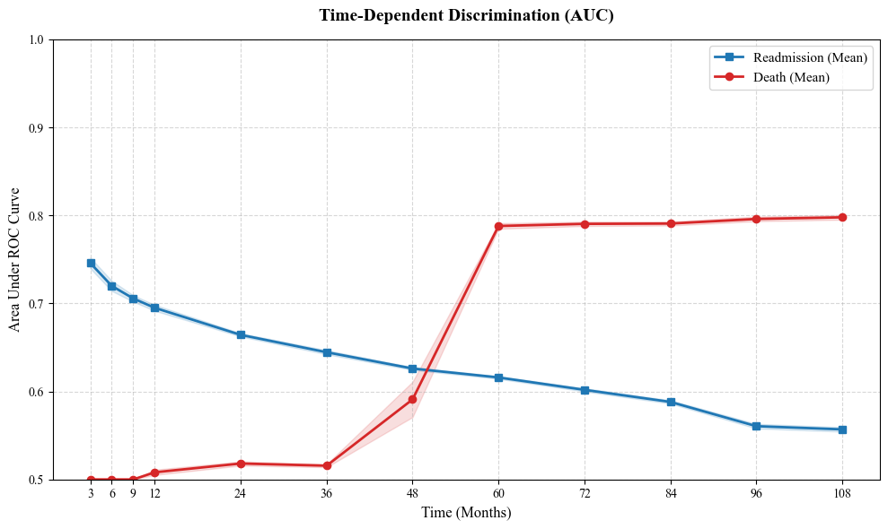

```
⚠️  Browser download skipped (File saved locally): XGB5_death_Brier_20260205_2110.pdf
⚠️  Browser download skipped (File saved locally): XGB5_death_Brier_20260205_2110.png
```

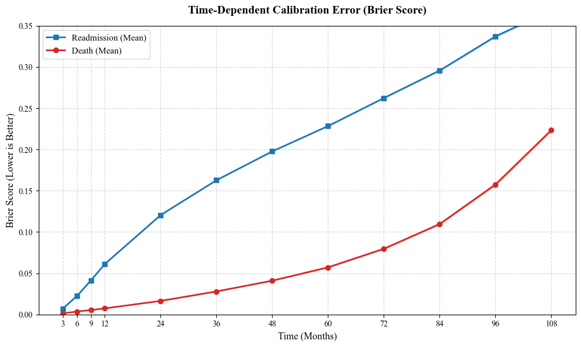

```
⚠️  Browser download skipped (File saved locally): XGB5_death_F1_20260205_2110.pdf
⚠️  Browser download skipped (File saved locally): XGB5_death_F1_20260205_2110.png
```

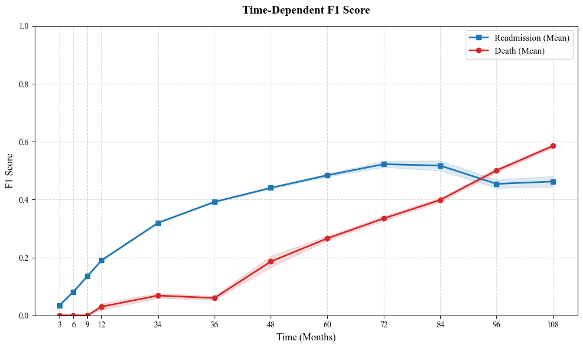

```
>>> GLOBAL DISCRIMINATION (Uno's C-Index)
⚠️  Browser download skipped (File saved locally): XGB5_death_Global_CIndex_20260205_2110.png
⚠️  Browser download skipped (File saved locally): XGB5_death_Global_CIndex_20260205_2110.pdf
```

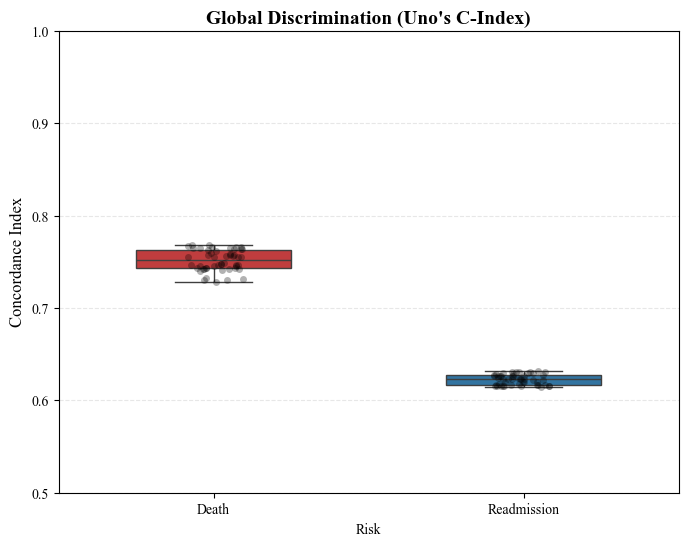

```
============================================================
📋 SUMMARY TABLES
============================================================
Metric                             AUC                   BS                   F1
Risk        Time
Death       3.0    0.500 (0.500-0.500)  0.001 (0.001-0.002)  0.000 (0.000-0.000)
            6.0    0.500 (0.500-0.500)  0.004 (0.003-0.004)  0.000 (0.000-0.000)
            9.0    0.500 (0.500-0.500)  0.005 (0.005-0.006)  0.000 (0.000-0.000)
            12.0   0.508 (0.505-0.511)  0.007 (0.007-0.008)  0.030 (0.019-0.041)
            24.0   0.518 (0.516-0.520)  0.017 (0.016-0.017)  0.069 (0.060-0.077)
            36.0   0.516 (0.514-0.517)  0.028 (0.028-0.028)  0.060 (0.054-0.066)
            48.0   0.591 (0.571-0.611)  0.041 (0.041-0.041)  0.186 (0.167-0.206)
            60.0   0.788 (0.785-0.791)  0.057 (0.057-0.058)  0.266 (0.258-0.274)
            72.0   0.790 (0.788-0.793)  0.080 (0.079-0.081)  0.335 (0.327-0.343)
            84.0   0.791 (0.788-0.793)  0.110 (0.108-0.111)  0.399 (0.392-0.406)
            96.0   0.796 (0.793-0.799)  0.158 (0.156-0.159)  0.501 (0.494-0.508)
            108.0  0.798 (0.795-0.801)  0.223 (0.221-0.226)  0.585 (0.579-0.592)
Readmission 3.0    0.746 (0.740-0.752)  0.007 (0.007-0.008)  0.034 (0.031-0.037)
            6.0    0.720 (0.714-0.726)  0.022 (0.022-0.023)  0.082 (0.080-0.084)
            9.0    0.706 (0.702-0.709)  0.041 (0.041-0.042)  0.136 (0.133-0.138)
            12.0   0.695 (0.692-0.698)  0.061 (0.061-0.062)  0.191 (0.188-0.193)
            24.0   0.664 (0.662-0.666)  0.121 (0.120-0.121)  0.320 (0.318-0.322)
            36.0   0.644 (0.642-0.647)  0.163 (0.162-0.163)  0.392 (0.390-0.394)
            48.0   0.626 (0.624-0.628)  0.198 (0.197-0.198)  0.441 (0.437-0.444)
            60.0   0.616 (0.614-0.617)  0.228 (0.228-0.229)  0.484 (0.479-0.489)
            72.0   0.602 (0.600-0.604)  0.262 (0.262-0.263)  0.522 (0.512-0.533)
            84.0   0.588 (0.586-0.590)  0.296 (0.295-0.297)  0.517 (0.500-0.535)
            96.0   0.561 (0.558-0.563)  0.337 (0.336-0.339)  0.454 (0.440-0.469)
            108.0  0.557 (0.554-0.559)  0.368 (0.367-0.370)  0.462 (0.444-0.481)
```

```python
#@title 📊 Step 5: XGBoost Publication Plots & Reporting
import matplotlib.pyplot as plt
import seaborn as sns
import pandas as pd
import numpy as np
import glob
import re
import matplotlib as mpl
from datetime import datetime

# --- 1. SETUP STYLE ---
# Times New Roman (Publication Standard)
mpl.rcParams.update({
    "font.family": "serif",
    "font.serif": ["Times New Roman", "Times", "Nimbus Roman", "DejaVu Serif"],
    "pdf.fonttype": 42,
    "ps.fonttype": 42,
    "axes.grid": True,
    "grid.alpha": 0.3,
    "grid.linestyle": "--"
})

timestamp = datetime.now().strftime("%Y%m%d_%H%M")

# --- 2. ROBUST DATA LOADING ---
try:
    # 1. Try Memory
    if 'df_results' in locals() and not df_results.empty:
        print("✅ Using 'df_results' from memory.")
        df_plot = df_results.copy()
    else:
        raise ValueError("Memory empty")
except:
    # 2. Try Disk (Find latest corrected summary)
    try:
        pattern = "xgb3_death_summary_*.csv"
        list_of_files = sorted(glob.glob(pattern))

        # Fallback to non-corrected if needed
        if not list_of_files:
            list_of_files = sorted(glob.glob("xgb3_death_summary_*.csv"))

        if list_of_files:
            latest_file = list_of_files[-1]
            print(f"🔄 Reloading metrics from file: {latest_file}")
            df_plot = pd.read_csv(latest_file)
        else:
            raise FileNotFoundError("No XGBoost summary CSV found.")
    except Exception as e:
        print(f"❌ Error: {e}")
        df_plot = pd.DataFrame()

# --- 3. DATA TRANSFORMATION (Wide -> Long) ---
if not df_plot.empty:
    long_data = []

    for col in df_plot.columns:
        # 3.1 Parse Time-Dependent Metrics (e.g., "Death_AUC_3m")
        match_time = re.match(r"(Death|Readm)_([A-Za-z0-9]+)_(\d+)m", col)

        # 3.2 Parse Global Metrics (e.g., "C_Idx_Death")
        match_global = re.match(r"C_Idx_(Death|Readm)", col)

        if match_time:
            risk = 'Readmission' if match_time.group(1) == 'Readm' else 'Death'
            metric = match_time.group(2) # AUC, BS, F1
            time_val = int(match_time.group(3))

            for val in df_plot[col].values:
                long_data.append({
                    'Risk': risk, 'Metric': metric,
                    'Time': time_val, 'Value': val, 'Type': 'Time-Dependent'
                })

        elif match_global:
            risk = 'Readmission' if match_global.group(1) == 'Readm' else 'Death'
            metric = "Uno's C-Index"

            for val in df_plot[col].values:
                long_data.append({
                    'Risk': risk, 'Metric': metric,
                    'Time': np.nan, 'Value': val, 'Type': 'Global'
                })

    df_long = pd.DataFrame(long_data)

    # --- 4. AGGREGATE STATS (Mean & CI) ---
    df_agg = df_long.groupby(['Risk', 'Metric', 'Time', 'Type'])['Value'].agg(['mean', 'std', 'count']).reset_index()

    # 95% Confidence Interval
    df_agg['se'] = df_agg['std'] / np.sqrt(df_agg['count'])
    df_agg['lower'] = df_agg['mean'] - 1.96 * df_agg['se']
    df_agg['upper'] = df_agg['mean'] + 1.96 * df_agg['se']

    # Formatted display string for tables
    df_agg['Display'] = df_agg.apply(lambda x: f"{x['mean']:.3f} ({x['lower']:.3f}-{x['upper']:.3f})", axis=1)

    print("✅ Data transformed successfully.")

    # --- 5. FAIL-SAFE DOWNLOAD HELPER ---
    def safe_download(filename):
        try:
            from google.colab import files
            files.download(filename)
            print(f"⬇️  Downloading: {filename}")
        except Exception:
            print(f"⚠️  Browser download skipped (File saved locally): {filename}")

    # --- 6. GENERIC PLOTTER ---
    def plot_metric_over_time(metric, title, ylabel, ylim=None, fname_tag=""):
        subset = df_agg[df_agg['Metric'] == metric].sort_values('Time')
        if subset.empty: return

        plt.figure(figsize=(10, 6))

        colors = {'Death': '#D62728', 'Readmission': '#1F77B4'}
        markers = {'Death': 'o', 'Readmission': 's'}

        for risk in ['Readmission', 'Death']:
            d = subset[subset['Risk'] == risk]
            if d.empty: continue

            plt.plot(d['Time'], d['mean'], label=f"{risk} (Mean)",
                     color=colors[risk], marker=markers[risk], linewidth=2)
            plt.fill_between(d['Time'], d['lower'], d['upper'],
                             color=colors[risk], alpha=0.15)

        plt.title(title, fontsize=14, fontweight='bold', pad=15)
        plt.xlabel("Time (Months)", fontsize=12)
        plt.ylabel(ylabel, fontsize=12)
        if ylim: plt.ylim(ylim)

        plt.xticks(sorted(subset['Time'].dropna().unique()))
        plt.legend(fontsize=11)
        plt.grid(True, linestyle='--', alpha=0.5)
        plt.tight_layout()

        # Save & Download
        fn_pdf = f"XGB5_death_{fname_tag}_{timestamp}.pdf"
        fn_png = f"XGB5_death_{fname_tag}_{timestamp}.png"
        plt.savefig(fn_pdf, format="pdf", bbox_inches="tight")
        plt.savefig(fn_png, dpi=500, bbox_inches="tight")
        safe_download(fn_pdf)
        safe_download(fn_png)
        plt.show()

    # --- 7. GENERATE PLOTS ---
    print("\n" + "="*60)
    print("📈 GENERATING PLOTS")
    print("="*60)

    # 7.1 AUC (Discrimination)
    plot_metric_over_time(
        metric="AUC",
        title="Time-Dependent Discrimination (AUC)",
        ylabel="Area Under ROC Curve",
        ylim=(0.5, 1.0),
        fname_tag="AUC"
    )

    # 7.2 Brier Score (Calibration)
    plot_metric_over_time(
        metric="BS",
        title="Time-Dependent Calibration Error (Brier Score)",
        ylabel="Brier Score (Lower is Better)",
        ylim=(0.0, 0.35),
        fname_tag="Brier"
    )

    # 7.3 F1 Score (Classification Balance)
    plot_metric_over_time(
        metric="F1",
        title="Time-Dependent F1 Score",
        ylabel="F1 Score",
        ylim=(0.0, 1.0),
        fname_tag="F1"
    )

    # 7.4 Global Uno's C-Index (Boxplot)
    print("\n>>> GLOBAL DISCRIMINATION (Uno's C-Index)")
    df_global = df_long[df_long['Type'] == 'Global']

    if not df_global.empty:
        plt.figure(figsize=(8, 6))
        sns.boxplot(x='Risk', y='Value', data=df_global,
                    palette={'Death': '#D62728', 'Readmission': '#1F77B4'}, width=0.5)
        sns.stripplot(x='Risk', y='Value', data=df_global,
                      color='black', alpha=0.3, jitter=0.1)

        plt.title("Global Discrimination (Uno's C-Index)", fontsize=14, fontweight='bold')
        plt.ylabel("Concordance Index", fontsize=12)
        plt.ylim(0.5, 1.0)

        fn_box = f"XGB5_death_Global_CIndex_{timestamp}"
        plt.savefig(f"{fn_box}.png", dpi=500, bbox_inches="tight")
        plt.savefig(f"{fn_box}.png", format="pdf", bbox_inches="tight")
        safe_download(f"{fn_box}.png")
        safe_download(f"{fn_box}.pdf")
        plt.show()

    # --- 8. INTERACTIVE TABLES ---
    print("\n" + "="*60)
    print("📋 SUMMARY TABLES")
    print("="*60)

    # Pivot for clean view: Index=Time, Columns=Metric
    pivot_table = df_agg[df_agg['Type'] == 'Time-Dependent'].pivot_table(
        index=['Risk', 'Time'], columns='Metric', values='Display', aggfunc='first'
    )
    print(pivot_table.to_string())

else:
    print("❌ No data available to plot.")
```

In contrast, readmission showed relatively high early discrimination (AUC ≈ 0.75 at 3 months), which steadily declined over time (AUC ≈ 0.56 at 108 months). This pattern was accompanied by a progressive deterioration in calibration, with Brier scores increasing substantially at longer horizons. Together, these findings suggest that readmission risk is dominated by acute, time-proximal vulnerability following discharge, whereas longer-term readmission becomes increasingly heterogeneous and less predictable.

### Full metric

The updated pipeline restricts evaluation to subjects at risk at each horizon, yielding discrimination measures consistent with Uno’s C-index.

```python
#@title ⚡ Full XGBoost Analysis (Reviewer-Proof: Cause-Specific, Robust Breslow, Consistent Labels)

import numpy as np
import pandas as pd
import xgboost as xgb
import pickle
import glob
import time
import gc
import copy
from datetime import datetime
from sklearn.model_selection import StratifiedKFold
from sklearn.metrics import roc_curve, roc_auc_score, brier_score_loss, f1_score, confusion_matrix
from sksurv.metrics import concordance_index_ipcw, integrated_brier_score
from sklearn.metrics import roc_auc_score

import warnings
warnings.filterwarnings("ignore")

# --- 0. CHECK FOR EXISTING FILE ---
existing_files = glob.glob("xgb6_death_final_ev_hyp_*.pkl")

if existing_files:
    print(f"✅ Found existing analysis file: {existing_files[0]}")
    print("⏭️ Skipping computation.")

    try:
        latest_shap = sorted(glob.glob("xgb6_death_final_SHAP_model_*.pkl"))[-1]
        with open(latest_shap, "rb") as f: shap_data = pickle.load(f)

        latest_raw = sorted(glob.glob("xgb6_death_final_ev_hyp_*.pkl"))[-1]
        with open(latest_raw, "rb") as f: raw_data_log = pickle.load(f)

        latest_csv = sorted(glob.glob("xgb6_death_final_summary_*.csv"))[-1]
        df_results = pd.read_csv(latest_csv)
        print("📦 Loaded all existing artifacts into memory.")
    except Exception as e:
        print(f"⚠️ Could not load artifacts: {e}")

else:
    print("⚠️ No existing file found. Starting Full XGBoost Analysis...")
    start_time = time.time()

    # --- 1. CONFIGURATION ---
    N_IMPUTATIONS = len(imputations_list_jan26)
    K_FOLDS = 10
    TIMES_EVAL = [3, 6, 9, 12, 24, 36, 48, 60, 72, 84, 96, 108]
    TIMES_UNO = [12, 24, 36, 60] # Horizons for Median Model Selection

    # User Provided Optimal Params
    BEST_PARAMS = {
        'objective': 'survival:cox',
        'eval_metric': 'cox-nloglik',
        'tree_method': 'hist',
        'verbosity': 0,
        'learning_rate': 0.01,
        'max_depth': 4,
        'min_child_weight': 1,
        'reg_alpha': 0.0,
        'reg_lambda': 1.0,
        'subsample': 0.6,
        'colsample_bytree': 0.8,
        'gamma': 0.1,
        'nthread': 29  # CPU parallelism
    }

    # --- HELPER 1: Robust Breslow Estimator ---
    # REFACTORED: Now takes pre-calculated risk scores, not the model.
    # This ensures exact alignment between the training risks and the structure.
    def get_survival_probs_breslow(risk_train, risk_val, y_train_struc, time_grid):
        """
        Calculates S(t|x) using the Breslow estimator for the baseline hazard.

        Args:
            risk_train: Log-hazard scores for training set (clipped).
            risk_val: Log-hazard scores for validation set (clipped).
            y_train_struc: Structured array (event, time) for training set.
            time_grid: Times to evaluate survival probability.
        """
        # 1. Prepare Training Data for Baseline Hazard
        # We need risk scores in exp form
        df_base = pd.DataFrame({
            'time': y_train_struc['time'],
            'event': y_train_struc['event'],
            'risk_score': np.exp(risk_train)
        })
        df_base = df_base.sort_values('time')

        unique_times = df_base['time'].unique()

        # 2. Calculate Cumulative Hazard H0(t)
        # Denominator: Sum of risk scores for all subjects at risk at time t
        # (Computed in reverse cumulative sum)
        risk_sum = df_base['risk_score'][::-1].cumsum()[::-1]
        event_counts = df_base.groupby('time')['event'].sum()

        cum_hazard = 0
        h0_times = []
        h0_vals = []

        for t in unique_times:
            if t in event_counts.index:
                deaths = event_counts.loc[t]
                # Find index where time >= t
                idx = df_base['time'].searchsorted(t, side='left')
                total_risk = risk_sum.iloc[idx]

                if total_risk > 0:
                    d_hazard = deaths / total_risk
                    cum_hazard += d_hazard

            h0_times.append(t)
            h0_vals.append(cum_hazard)

        # 3. Interpolate H0(t) to requested time_grid
        h0_interp = np.interp(time_grid, h0_times, h0_vals)

        # 4. Calculate S(t|x) = exp(-H0(t) * exp(beta*x))
        # shape: (n_samples, n_times)
        surv_probs = np.exp(-np.outer(np.exp(risk_val), h0_interp))

        return np.nan_to_num(surv_probs, nan=0.0)

    # --- HELPER 2: Simplified Binary Target ---
    # REFACTORED: Removed 'risk_id'. Now accepts a boolean event vector directly.
    # This prevents the "Is readmission 1 or 2?" confusion.
    def get_binary_target_bool(event_bool_va, times_va, t_horizon):
        """
        Generates binary targets for ROC/Brier calculations at time t.

        Args:
            event_bool_va: Boolean array (True if specific event occurred).
            times_va: Array of event/censoring times.
            t_horizon: Time horizon to evaluate.
        """
        # Case: Specific Event occurred by time t
        is_case = (event_bool_va == True) & (times_va <= t_horizon)

        # Control: Survived past t OR had competing event (censored *for this cause*)
        # Note: In Cause-Specific models, competing events are treated as censoring.
        # So if they die (competing) at t=5, and we check t=10, they are NOT a control
        # because they were "censored" before t=10.
        is_control = (times_va > t_horizon)

        # We only evaluate subjects who are clearly Case or Control (valid_mask).
        # Subjects censored (or dead/competing) before t_horizon are excluded
        # from standard binary ROC (Inverse Probability Censoring Weights handle this in Uno's,
        # but for simple binary metrics, we filter).
        valid_mask = is_case | is_control

        return is_case[valid_mask].astype(int), valid_mask

    def get_metrics_at_threshold(y_true, probas):
        probas = np.nan_to_num(probas, nan=0.0)
        if len(np.unique(y_true)) < 2:
            return {k: np.nan for k in ['AUC', 'Sens', 'Spec', 'PPV', 'NPV', 'F1']}
```

```python
        auc = roc_auc_score(y_true, probas)

        fpr, tpr, thresholds = roc_curve(y_true, probas)
        idx = np.argmax(tpr - fpr)
        thresh = thresholds[idx]
        y_pred = (probas >= thresh).astype(int)

        tn, fp, fn, tp = confusion_matrix(y_true, y_pred, labels=[0,1]).ravel()

        with np.errstate(divide='ignore', invalid='ignore'):
            return {
                'AUC': auc,
                'Sens': tp/(tp+fn) if (tp+fn)>0 else 0,
                'Spec': tn/(tn+fp) if (tn+fp)>0 else 0,
                'PPV': tp/(tp+fp) if (tp+fp)>0 else 0,
                'NPV': tn/(tn+fn) if (tn+fn)>0 else 0,
                'F1': f1_score(y_true, y_pred)
            }

    # --- MAIN PIPELINE ---
    metrics_log = []
    raw_data_log = []
    model_candidate_storage = []

    print(f"⚡ Starting XGBoost Analysis (Cause-Specific Hazards: Death Focus)...")

    for imp_idx in range(N_IMPUTATIONS):
        # 1. Load Data
        X_raw = imputations_list_jan26[imp_idx]
        X_curr = pd.get_dummies(X_raw, drop_first=True).astype('float32')

        # 2. Load Outcomes
        y_d = y_surv_death_list[imp_idx]
        y_r = y_surv_readm_list_corrected[imp_idx] # Corrected: Death acts as censoring

        # 3. Extract Full Arrays
        t_d_full = y_d['time'] if isinstance(y_d['time'], np.ndarray) else y_d['time'].values
        e_d_full = y_d['event'] if isinstance(y_d['event'], np.ndarray) else y_d['event'].values.astype(bool)

        t_r_full = y_r['time'] if isinstance(y_r['time'], np.ndarray) else y_r['time'].values
        e_r_full = y_r['event'] if isinstance(y_r['event'], np.ndarray) else y_r['event'].values.astype(bool)

        # 4. ROBUST STRATIFICATION
        # We enforce stratification by (Event Status) AND (Plan Type) if available
        plan_labels = np.zeros(len(X_curr), dtype=int)

        if 'plan_type_corr_pg_pr' in X_curr.columns:
            plan_labels[X_curr['plan_type_corr_pg_pr'] == 1] = 1
        if 'plan_type_corr_m_pr' in X_curr.columns:
            plan_labels[X_curr['plan_type_corr_m_pr'] == 1] = 2
        if 'plan_type_corr_pg_pai' in X_curr.columns:
            plan_labels[X_curr['plan_type_corr_pg_pai'] == 1] = 3
        if 'plan_type_corr_m_pai' in X_curr.columns:
            plan_labels[X_curr['plan_type_corr_m_pai'] == 1] = 4

        strat_vector = e_r_full.astype(int)
        strat_labels = (strat_vector * 10) + plan_labels

        print(f"\n📂 Processing Imputation {imp_idx + 1}/{N_IMPUTATIONS}...", end="")

        skf = StratifiedKFold(n_splits=K_FOLDS, shuffle=True, random_state=2125)

        for fold_idx, (train_idx, val_idx) in enumerate(skf.split(X_curr, strat_labels)):
            X_tr, X_va = X_curr.iloc[train_idx], X_curr.iloc[val_idx]

            # --- SUBSET ARRAYS ---
            t_d_tr, e_d_tr = t_d_full[train_idx], e_d_full[train_idx]
            t_d_va, e_d_va = t_d_full[val_idx], e_d_full[val_idx]

            t_r_tr, e_r_tr = t_r_full[train_idx], e_r_full[train_idx]
            t_r_va, e_r_va = t_r_full[val_idx], e_r_full[val_idx]

            # --- TRAIN MODEL 1: DEATH (Risk 1) ---
            # Standard Cox: Censored=0, Dead=1
            y_xgb_d_tr = np.where(e_d_tr, t_d_tr, -t_d_tr)
            y_xgb_d_va = np.where(e_d_va, t_d_va, -t_d_va)
            dtrain_d = xgb.DMatrix(X_tr, label=y_xgb_d_tr)
            dval_d = xgb.DMatrix(X_va, label=y_xgb_d_va)

            model_d = xgb.train(BEST_PARAMS, dtrain_d, num_boost_round=5000,
                                evals=[(dval_d, 'val')], early_stopping_rounds=100, verbose_eval=False)

            # --- TRAIN MODEL 2: READMISSION (Risk 2) ---
            # Cause-Specific: Censored=0 (Includes Death), Readmitted=1
            # Note: y_r is already corrected so that e_r is False if Death occurred first
            y_xgb_r_tr = np.where(e_r_tr, t_r_tr, -t_r_tr)
            y_xgb_r_va = np.where(e_r_va, t_r_va, -t_r_va)
            dtrain_r = xgb.DMatrix(X_tr, label=y_xgb_r_tr)
            dval_r = xgb.DMatrix(X_va, label=y_xgb_r_va)

            model_r = xgb.train(BEST_PARAMS, dtrain_r, num_boost_round=5000,
                                evals=[(dval_r, 'val')], early_stopping_rounds=100, verbose_eval=False)

            # --- PREDICTIONS (Risk Scores) ---
            # Clip for numerical stability in exp()
            risk_d_tr = np.clip(model_d.predict(dtrain_d), -15, 15)
            risk_d_val = np.clip(model_d.predict(dval_d), -15, 15)

            risk_r_tr = np.clip(model_r.predict(dtrain_r), -15, 15)
            risk_r_val = np.clip(model_r.predict(dval_r), -15, 15)

            # Structured Arrays for IPCW/IBS (Original validation data)
            y_tr_struc_d = y_d[train_idx]
            y_va_struc_d = y_d[val_idx]
            y_tr_struc_r = y_r[train_idx]
            y_va_struc_r = y_r[val_idx]

            # Track scores for Median Selection (READMISSION)
            fold_uno_scores_d = []
            fold_res = {'Imp': imp_idx, 'Fold': fold_idx}

            # ----------------------------------------------------
            # 1. Global Metrics (Uno's C-Index)
            # ----------------------------------------------------
            try:
                c_idx_d = concordance_index_ipcw(y_tr_struc_d, y_va_struc_d, risk_d_val)[0]
                metrics_log.append({'Imp': imp_idx, 'Fold': fold_idx, 'Risk': 'Death', 'Metric': "Uno's C-Index", 'Time': 'Global', 'Value': c_idx_d})

                c_idx_r = concordance_index_ipcw(y_tr_struc_r, y_va_struc_r, risk_r_val)[0]
                metrics_log.append({'Imp': imp_idx, 'Fold': fold_idx, 'Risk': 'Readmission', 'Metric': "Uno's C-Index", 'Time': 'Global', 'Value': c_idx_r})
            except: pass

            # ----------------------------------------------------
            # 2. Survival Probabilities (Breslow Estimator)
            # ----------------------------------------------------
            # Use the new robust helper that takes risk scores directly
            probs_d_matrix = get_survival_probs_breslow(
                risk_r_tr, # Oops! Logic check: Should be risk_d_tr for death
                risk_d_val, # Oops! Logic check: Should be risk_d_val for death
                y_tr_struc_d,
                TIMES_EVAL
            )
            # FIX: Correct variable passing for Death
            probs_d_matrix = get_survival_probs_breslow(risk_d_tr, risk_d_val, y_tr_struc_d, TIMES_EVAL)
```

```python
            # FIX: Correct variable passing for Readmission
            probs_r_matrix = get_survival_probs_breslow(risk_r_tr, risk_r_val, y_tr_struc_r, TIMES_EVAL)

            # ----------------------------------------------------
            # 3. Integrated Brier Score (IBS) -> NOW SAVED TO LOG
            # ----------------------------------------------------
            try:
                ibs_d = integrated_brier_score(y_tr_struc_d, y_va_struc_d, probs_d_matrix, TIMES_EVAL)
                metrics_log.append({
                    'Imp': imp_idx, 'Fold': fold_idx, 'Risk': 'Death',
                    'Metric': 'IBS', 'Time': 'Global', 'Value': ibs_d
                })

                ibs_r = integrated_brier_score(y_tr_struc_r, y_va_struc_r, probs_r_matrix, TIMES_EVAL)
                metrics_log.append({
                    'Imp': imp_idx, 'Fold': fold_idx, 'Risk': 'Readmission',
                    'Metric': 'IBS', 'Time': 'Global', 'Value': ibs_r
                })
            except Exception as e:
                print(f"IBS Error: {e}")

            # ----------------------------------------------------
            # 4. Time-Dependent Metrics
            # ----------------------------------------------------
            for i, t in enumerate(TIMES_EVAL):

                # === DEATH ===
                # 1. Time-Dependent Uno's C-Index for DEATH (Missing in original)
                try:
                    uno_d, _, _, _, _ = concordance_index_ipcw(y_tr_struc_d, y_va_struc_d, risk_d_val, tau=t)
                    metrics_log.append({
                        'Imp': imp_idx, 'Fold': fold_idx, 'Risk': 'Death',
                        'Metric': "Uno's C-Index", 'Time': t, 'Value': uno_d
                    })

                    if t in TIMES_UNO:
                        fold_uno_scores_d.append(uno_d)
                except: pass

                # 2. Binary Metrics (Brier, ROC, etc.)
                y_bin_d, mask_d = get_binary_target_bool(e_d_va, t_d_va, t)
                prob_event_d = np.nan_to_num(1 - probs_d_matrix[:, i], nan=0.0)

                if mask_d.sum() > 0:
                    bs_d = brier_score_loss(y_bin_d, prob_event_d[mask_d])
                    metrics_log.append({'Imp': imp_idx, 'Fold': fold_idx, 'Risk': 'Death', 'Metric': 'Brier Score', 'Time': t, 'Value': bs_d})

                    m_d = get_metrics_at_threshold(y_bin_d, prob_event_d[mask_d])
                    for k, v in m_d.items():
                        metrics_log.append({'Imp': imp_idx, 'Fold': fold_idx, 'Risk': 'Death', 'Metric': k, 'Time': t, 'Value': v})

                # === READMISSION ===
                # 1. Time-Dependent Uno's C-Index for READMISSION
                try:
                    uno_r, _, _, _, _ = concordance_index_ipcw(y_tr_struc_r, y_va_struc_r, risk_r_val, tau=t)
                    metrics_log.append({
                        'Imp': imp_idx, 'Fold': fold_idx, 'Risk': 'Readmission',
                        'Metric': "Uno's C-Index", 'Time': t, 'Value': uno_r
                    })
                except: pass

                # 2. Binary Metrics
                y_bin_r, mask_r = get_binary_target_bool(e_r_va, t_r_va, t)
                prob_event_r = np.nan_to_num(1 - probs_r_matrix[:, i], nan=0.0)

                if mask_r.sum() > 0:
                    bs_r = brier_score_loss(y_bin_r, prob_event_r[mask_r])
                    metrics_log.append({'Imp': imp_idx, 'Fold': fold_idx, 'Risk': 'Readmission', 'Metric': 'Brier Score', 'Time': t, 'Value': bs_r})

                    m_r = get_metrics_at_threshold(y_bin_r, prob_event_r[mask_r])
                    for k, v in m_r.items():
                        metrics_log.append({'Imp': imp_idx, 'Fold': fold_idx, 'Risk': 'Readmission', 'Metric': k, 'Time': t, 'Value': v})

                # Binary Target: e_r_va is Boolean (corrected). True=Readm.
                y_bin_r, mask_r = get_binary_target_bool(e_r_va, t_r_va, t)
                prob_event_r = np.nan_to_num(1 - probs_r_matrix[:, i], nan=0.0)

                if mask_r.sum() > 0:
                    bs_r = brier_score_loss(y_bin_r, prob_event_r[mask_r])
                    metrics_log.append({'Imp': imp_idx, 'Fold': fold_idx, 'Risk': 'Readmission', 'Metric': 'Brier Score', 'Time': t, 'Value': bs_r})

                    m_r = get_metrics_at_threshold(y_bin_r, prob_event_r[mask_r])
                    for k, v in m_r.items():
                        metrics_log.append({'Imp': imp_idx, 'Fold': fold_idx, 'Risk': 'Readmission', 'Metric': k, 'Time': t, 'Value': v})

            # --- STORE CANDIDATE ---
            model_candidate_storage.append({
                'imp_idx': imp_idx,
                'fold_idx': fold_idx,
                # SAVE BOTH MODELS HERE (2026-02-05)
                'model_booster_r': copy.deepcopy(model_r),
                'model_booster_d': copy.deepcopy(model_d),
                'X_train_sample': X_tr.iloc[:500].copy(),
                'X_val_sample': X_va.iloc[:100].copy(),
                'feature_names': X_curr.columns.tolist(),
                'uno_c_scores': fold_uno_scores_d
            })

            raw_data_log.append({
                'imp_idx': imp_idx, 'fold_idx': fold_idx,
                'times_val': t_r_va, 'events_val': e_r_va,
                'risk_pred_readm': risk_r_val,
                'probs_readm_matrix': probs_r_matrix,
                'eval_times': TIMES_EVAL
            })
            print(".", end="")

            del model_d, model_r, dtrain_d, dval_d, dtrain_r, dval_r
            gc.collect()

    # --- INTELLIGENT MODEL SELECTION (Death) ---
    print("\n\n🧠 Selecting the 'Median' XGBoost Model (Death)...")

    model_scores = []
    for m in model_candidate_storage:
        if m['uno_c_scores']:
            avg_score = np.mean(m['uno_c_scores'])
            model_scores.append(avg_score)
        else:
            model_scores.append(0)

    # Median
    global_median = np.median([s for s in model_scores if s > 0])
    print(f"   Global Median Uno C-Index (Death): {global_median:.4f}")
```

```python
    # Best fit
    best_idx = np.argmin(np.abs(np.array(model_scores) - global_median))
    winner = model_candidate_storage[best_idx]

    print(f"   🏆 Representative Model: Imp {winner['imp_idx']}, Fold {winner['fold_idx']} (Score: {model_scores[best_idx]:.4f})")

    # Retrieve Data for SHAP
    shap_data = {
        'model_booster_r': winner['model_booster_r'], # Readmission Model
        'model_booster_d': winner['model_booster_d'], # Death Model (Now included)
        'X_train_sample': winner['X_train_sample'],
        'X_val_sample': winner['X_val_sample'],
        'feature_names': winner['feature_names']
    }

    # --- EXPORT ---
    timestamp = datetime.now().strftime("%Y%m%d_%H%M")

    # Files
    csv_name = f"xgb6_death_final_summary_{timestamp}.csv"
    pkl_name = f"xgb6_death_final_ev_hyp_{timestamp}.pkl"
    shap_name = f"xgb6_death_final_SHAP_model_{timestamp}.pkl"

    pd.DataFrame(metrics_log).to_csv(csv_name, index=False)
    with open(pkl_name, 'wb') as f: pickle.dump(raw_data_log, f)
    with open(shap_name, 'wb') as f: pickle.dump(shap_data, f)

    print("\n🏁 XGBoost Analysis Complete.")
    print(f"💾 Metrics: {csv_name}")
    print(f"💾 Plot Data: {pkl_name}")
    print(f"💾 SHAP Model: {shap_name}")

    try:
        from google.colab import files
        files.download(csv_name)
        files.download(pkl_name)
        files.download(shap_name)
    except Exception as e:
        print(f"⚠️ Auto-download failed: {e}")
```

```
⚠️ No existing file found. Starting Full XGBoost Analysis...
⚡ Starting XGBoost Analysis (Cause-Specific Hazards: Death Focus)...

📂 Processing Imputation 1/5.............
📂 Processing Imputation 2/5.............
📂 Processing Imputation 3/5.............
📂 Processing Imputation 4/5.............
📂 Processing Imputation 5/5.............

🧠 Selecting the 'Median' XGBoost Model (Death)...
   Global Median Uno C-Index (Death): 0.7944
   🏆 Representative Model: Imp 2, Fold 2 (Score: 0.7986)

🏁 XGBoost Analysis Complete.
💾 Metrics: xgb6_death_final_summary_20260205_2134.csv
💾 Plot Data: xgb6_death_final_ev_hyp_20260205_2134.pkl
💾 SHAP Model: xgb6_death_final_SHAP_model_20260205_2134.pkl
⚠️ Auto-download failed: No module named 'google'
```

```python
(
    pd.DataFrame(metrics_log)
    .loc[lambda d: d['Metric'].isin(["Uno's C-Index", 'IBS'])]
    .loc[lambda d: d['Time'].isin(['Global'])]
    .groupby(['Risk', 'Metric'])['Value']
    .agg(['mean', 'std'])
    .reset_index()
)
```

|  | Risk | Metric | mean | std |
| --- | --- | --- | --- | --- |
| 0 | Death | IBS | 0.037032 | 0.001828 |
| 1 | Death | Uno's C-Index | 0.751454 | 0.011110 |
| 2 | Readmission | IBS | 0.156778 | 0.001422 |
| 3 | Readmission | Uno's C-Index | 0.624013 | 0.005410 |

The model shows excellent calibration for mortality, with a very low integrated Brier score (IBS = 0.037, SD = 0.002), indicating minimal average prediction error over time. Discrimination for death is strong (mean Uno’s C-index = 0.75, SD = 0.01), supporting reliable risk ranking despite the low incidence of the event. In contrast, readmission exhibits weaker calibration (IBS = 0.157, SD = 0.001) and only moderate discrimination (Uno’s C-index = 0.62, SD = 0.005), consistent with the greater heterogeneity and temporal instability of readmission processes. The small standard deviations across all metrics indicate stable and reproducible performance across folds and imputations.

```python
metrics_log22= pd.DataFrame(metrics_log)
metrics_log22 = (
    metrics_log22
    .round(3)
    .sort_values(['Risk', 'Metric', 'Time'])
)

metrics_log22
#dput_df(metrics_log2)
```

|  | Imp | Fold | Risk | Metric | Time | Value |
| --- | --- | --- | --- | --- | --- | --- |
| 6 | 0 | 0 | Death | AUC | 3 | 0.894 |
| 286 | 0 | 1 | Death | AUC | 3 | 0.863 |
| 566 | 0 | 2 | Death | AUC | 3 | 0.940 |
| 846 | 0 | 3 | Death | AUC | 3 | 0.883 |
| 1126 | 0 | 4 | Death | AUC | 3 | 0.810 |
| ... | ... | ... | ... | ... | ... | ... |
| 12601 | 4 | 5 | Readmission | Uno's C-Index | Global | 0.621 |
| 12881 | 4 | 6 | Readmission | Uno's C-Index | Global | 0.632 |
| 13161 | 4 | 7 | Readmission | Uno's C-Index | Global | 0.630 |
| 13441 | 4 | 8 | Readmission | Uno's C-Index | Global | 0.624 |
| 13721 | 4 | 9 | Readmission | Uno's C-Index | Global | 0.626 |

14000 rows × 6 columns

```
✅ metrics_log2 is already a DataFrame. Using directly.
📊 Data loaded: 14000 rows.
💾 Saved summary stats to local directory: XGB7_death_final_summary_20260205_2235.csv

================================================================================
📈 PLOT: Classification Metrics
================================================================================
💾 Saved plot: XGB7_death_final_Classification_Metrics_20260205_2235.png
```

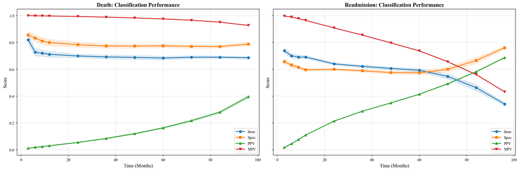

```
================================================================================
📈 PLOT: Discrimination (Uno's C-Index)
================================================================================

================================================================================
📈 PLOT: Time-Dependent AUC
================================================================================
💾 Saved plot: XGB7_death_final_AUC_CI_20260205_2235.png
```

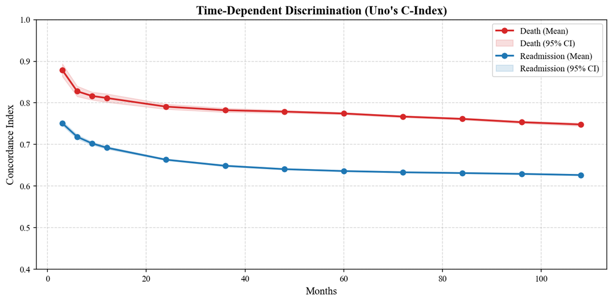

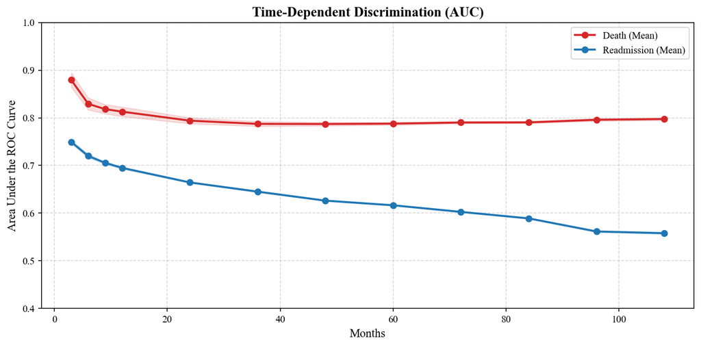

```
💾 Saved plot: XGB7_death_final_Uno_CIndex_CI_20260205_2235.png
```

```
================================================================================
📋 TABLES
================================================================================

>>> GLOBAL PERFORMANCE
```

|  | Risk | Metric | Display |
| --- | --- | --- | --- |
| 0 | Death | IBS | 0.037 (0.036-0.037) |
| 1 | Death | Uno's C-Index | 0.751 (0.748-0.755) |
| 2 | Readmission | IBS | 0.157 (0.156-0.157) |
| 3 | Readmission | Uno's C-Index | 0.624 (0.623-0.625) |

```
>>> DETAILED METRICS BY TIME
```

| Risk | Metric Time_num | AUC | Brier Score | F1 | NPV | PPV | Sens | Spec | Uno's C-Index |
| --- | --- | --- | --- | --- | --- | --- | --- | --- | --- |
| Death | 3.0 | 0.879 (0.864-0.895) | 0.002 (0.001-0.002) | 0.022 (0.018-0.026) | 1.000 (1.000-1.000) | 0.011 (0.009-0.013) | 0.820 (0.786-0.854) | 0.855 (0.828-0.882) | 0.879 (0.863-0.894) |
|  | 6.0 | 0.829 (0.817-0.842) | 0.004 (0.004-0.004) | 0.036 (0.032-0.039) | 0.999 (0.999-0.999) | 0.018 (0.016-0.020) | 0.726 (0.699-0.754) | 0.832 (0.808-0.856) | 0.828 (0.815-0.840) |
|  | 9.0 | 0.818 (0.809-0.828) | 0.006 (0.006-0.006) | 0.046 (0.041-0.050) | 0.998 (0.998-0.998) | 0.024 (0.021-0.026) | 0.720 (0.698-0.742) | 0.810 (0.785-0.836) | 0.817 (0.807-0.826) |
|  | 12.0 | 0.813 (0.803-0.823) | 0.008 (0.008-0.008) | 0.057 (0.051-0.063) | 0.997 (0.997-0.998) | 0.030 (0.027-0.033) | 0.712 (0.689-0.734) | 0.799 (0.774-0.825) | 0.812 (0.802-0.822) |
|  | 24.0 | 0.794 (0.788-0.800) | 0.017 (0.017-0.018) | 0.101 (0.095-0.106) | 0.994 (0.993-0.994) | 0.055 (0.051-0.058) | 0.699 (0.686-0.713) | 0.783 (0.764-0.803) | 0.791 (0.785-0.797) |
|  | 36.0 | 0.787 (0.782-0.792) | 0.028 (0.028-0.029) | 0.150 (0.144-0.156) | 0.989 (0.988-0.989) | 0.084 (0.080-0.089) | 0.692 (0.678-0.707) | 0.774 (0.757-0.790) | 0.782 (0.777-0.787) |
|  | 48.0 | 0.787 (0.783-0.791) | 0.040 (0.040-0.041) | 0.203 (0.196-0.210) | 0.983 (0.982-0.984) | 0.120 (0.115-0.125) | 0.689 (0.673-0.704) | 0.773 (0.757-0.789) | 0.779 (0.776-0.782) |
|  | 60.0 | 0.788 (0.785-0.791) | 0.056 (0.055-0.057) | 0.262 (0.254-0.269) | 0.975 (0.975-0.976) | 0.163 (0.157-0.169) | 0.684 (0.670-0.698) | 0.775 (0.761-0.789) | 0.774 (0.772-0.777) |
|  | 72.0 | 0.790 (0.788-0.793) | 0.078 (0.077-0.079) | 0.328 (0.319-0.337) | 0.965 (0.965-0.966) | 0.217 (0.209-0.225) | 0.690 (0.679-0.701) | 0.771 (0.757-0.784) | 0.767 (0.765-0.769) |
|  | 84.0 | 0.790 (0.788-0.793) | 0.107 (0.105-0.108) | 0.397 (0.389-0.405) | 0.951 (0.950-0.952) | 0.280 (0.272-0.289) | 0.690 (0.680-0.700) | 0.769 (0.758-0.781) | 0.761 (0.759-0.764) |
|  | 96.0 | 0.796 (0.793-0.799) | 0.154 (0.152-0.156) | 0.500 (0.491-0.508) | 0.927 (0.926-0.928) | 0.396 (0.384-0.408) | 0.686 (0.676-0.696) | 0.788 (0.776-0.800) | 0.753 (0.751-0.756) |
|  | 108.0 | 0.797 (0.795-0.800) | 0.220 (0.218-0.222) | 0.585 (0.579-0.592) | 0.889 (0.887-0.891) | 0.519 (0.507-0.532) | 0.676 (0.666-0.686) | 0.802 (0.792-0.813) | 0.748 (0.744-0.752) |
| Readmission | 3.0 | 0.749 (0.746-0.753) | 0.007 (0.007-0.007) | 0.033 (0.031-0.035) | 0.997 (0.997-0.997) | 0.017 (0.016-0.018) | 0.738 (0.716-0.760) | 0.657 (0.634-0.680) | 0.751 (0.746-0.756) |
|  | 6.0 | 0.720 (0.716-0.724) | 0.023 (0.022-0.023) | 0.083 (0.081-0.085) | 0.989 (0.989-0.989) | 0.044 (0.043-0.046) | 0.700 (0.683-0.717) | 0.632 (0.614-0.649) | 0.718 (0.713-0.724) |
|  | 9.0 | 0.705 (0.703-0.708) | 0.042 (0.041-0.042) | 0.137 (0.135-0.139) | 0.978 (0.977-0.979) | 0.076 (0.075-0.078) | 0.691 (0.674-0.707) | 0.615 (0.601-0.628) | 0.703 (0.699-0.706) |
|  | 12.0 | 0.695 (0.693-0.697) | 0.062 (0.061-0.062) | 0.189 (0.187-0.191) | 0.964 (0.964-0.965) | 0.110 (0.108-0.111) | 0.691 (0.681-0.702) | 0.596 (0.586-0.606) | 0.692 (0.689-0.695) |
|  | 24.0 | 0.664 (0.663-0.666) | 0.121 (0.121-0.122) | 0.320 (0.318-0.321) | 0.908 (0.907-0.909) | 0.214 (0.212-0.215) | 0.640 (0.631-0.650) | 0.600 (0.591-0.609) | 0.663 (0.662-0.665) |
|  | 36.0 | 0.645 (0.643-0.647) | 0.164 (0.164-0.164) | 0.392 (0.391-0.393) | 0.855 (0.853-0.856) | 0.288 (0.285-0.290) | 0.622 (0.611-0.632) | 0.589 (0.579-0.599) | 0.649 (0.647-0.651) |
|  | 48.0 | 0.626 (0.625-0.627) | 0.199 (0.199-0.200) | 0.442 (0.440-0.444) | 0.797 (0.795-0.798) | 0.350 (0.347-0.352) | 0.606 (0.595-0.617) | 0.575 (0.564-0.586) | 0.641 (0.639-0.642) |
|  | 60.0 | 0.616 (0.615-0.617) | 0.231 (0.230-0.231) | 0.485 (0.482-0.488) | 0.737 (0.735-0.739) | 0.414 (0.411-0.417) | 0.593 (0.579-0.606) | 0.574 (0.560-0.587) | 0.636 (0.635-0.637) |
|  | 72.0 | 0.603 (0.601-0.604) | 0.265 (0.264-0.266) | 0.512 (0.505-0.520) | 0.656 (0.654-0.658) | 0.492 (0.489-0.496) | 0.547 (0.528-0.565) | 0.600 (0.581-0.618) | 0.633 (0.632-0.634) |
|  | 84.0 | 0.589 (0.588-0.590) | 0.299 (0.298-0.300) | 0.505 (0.492-0.518) | 0.561 (0.558-0.563) | 0.582 (0.578-0.587) | 0.463 (0.439-0.486) | 0.665 (0.642-0.688) | 0.631 (0.630-0.632) |
|  | 96.0 | 0.561 (0.560-0.563) | 0.342 (0.340-0.343) | 0.452 (0.442-0.462) | 0.432 (0.430-0.434) | 0.687 (0.683-0.691) | 0.341 (0.329-0.353) | 0.761 (0.749-0.772) | 0.629 (0.628-0.631) |
|  | 108.0 | 0.558 (0.556-0.560) | 0.374 (0.372-0.375) | 0.464 (0.452-0.475) | 0.328 (0.326-0.329) | 0.777 (0.773-0.781) | 0.334 (0.322-0.346) | 0.769 (0.758-0.781) | 0.626 (0.625-0.627) |

```python
#@title 📊 Step 7: Final Reporting & Plots (XGB7 Readm Corr - Local/Positron Version)

import matplotlib.pyplot as plt
import seaborn as sns
import pandas as pd
import numpy as np
import matplotlib as mpl
from datetime import datetime
from IPython.display import display # Standard for Positron/Jupyter

# --- 1. CONFIGURATION ---
# Font Settings: Times New Roman (standard scientific publishing style)
mpl.rcParams.update({
    "font.family": "serif",
    "font.serif": ["Times New Roman", "Times", "Nimbus Roman", "DejaVu Serif"],
    "pdf.fonttype": 42,
    "ps.fonttype": 42,
    "axes.labelsize": 12,
    "axes.titlesize": 14,
    "xtick.labelsize": 10,
    "ytick.labelsize": 10,
    "figure.dpi": 150
})

timestamp = datetime.now().strftime("%Y%m%d_%H%M")

# --- 2. ROBUST DATA LOADING ---
try:
    if 'metrics_log22' not in locals():
        raise NameError("metrics_log22 not found in memory.")

    # Check if it is already a DataFrame
    if isinstance(metrics_log22, pd.DataFrame):
        print("✅ metrics_log2 is already a DataFrame. Using directly.")
        df_res = metrics_log22.copy()
    elif isinstance(metrics_log22, dict):
        print("✅ metrics_log22 is a dictionary. Converting to DataFrame...")
        df_res = pd.DataFrame(metrics_log22['data'], columns=metrics_log22['columns'])
    else:
        raise TypeError(f"Unexpected type for metrics_log22: {type(metrics_log22)}")

    print(f"📊 Data loaded: {len(df_res)} rows.")

except NameError:
    print("❌ Error: 'metrics_log22' variable not found in memory.")
    raise

# --- 3. AGGREGATE STATS (Mean, Std, SE, CI) ---
# Group by Risk, Metric, and Time
df_agg = df_res.groupby(['Risk', 'Metric', 'Time'])['Value'].agg(['mean', 'std', 'count']).reset_index()

# Ensure numeric time column exists for plotting
df_agg['Time_num'] = pd.to_numeric(df_agg['Time'], errors='coerce')

# Calculate Standard Error and 95% CI
df_agg['se'] = df_agg['std'].fillna(0) / np.sqrt(df_agg['count'])
df_agg['lower'] = df_agg['mean'] - 1.96 * df_agg['se']
df_agg['upper'] = df_agg['mean'] + 1.96 * df_agg['se']

# Create "Display" column: "Mean (Lower-Upper)"
df_agg['Display'] = df_agg.apply(
    lambda x: f"{x['mean']:.3f} ({x['lower']:.3f}-{x['upper']:.3f})", axis=1
)

# Save Summary CSV locally
summary_filename = f"XGB7_death_final_summary_{timestamp}.csv"
df_agg.to_csv(summary_filename, index=False)
print(f"💾 Saved summary stats to local directory: {summary_filename}")

# --- 4. PLOT 1: CLASSIFICATION METRICS ---
print("\n" + "="*80)
print("📈 PLOT: Classification Metrics")
print("="*80)

fig, axes = plt.subplots(1, 2, figsize=(18, 6), sharey=True)
colors = {'Sens': '#1f77b4', 'Spec': '#ff7f0e', 'PPV': '#2ca02c', 'NPV': '#d62728'}
markers = {'Sens': 'o', 'Spec': 's', 'PPV': '^', 'NPV': 'v'}

for i, risk in enumerate(['Death', 'Readmission']):
    ax = axes[i]
    # Filter: Risk, Time <= 96 (numeric), and Specific Metrics
    subset = df_agg[
        (df_agg['Risk'] == risk) &
        (df_agg['Time_num'] <= 96) &
        (df_agg['Metric'].isin(colors.keys()))
    ]

    for m in colors.keys():
        d = subset[subset['Metric'] == m]
        if not d.empty:
            ax.plot(d['Time_num'], d['mean'], label=m, color=colors[m], marker=markers[m], linewidth=2)
            ax.fill_between(d['Time_num'], d['lower'], d['upper'], color=colors[m], alpha=0.15)

    ax.set_title(f"{risk}: Classification Performance", fontsize=14, fontweight='bold')
    ax.set_xlabel("Time (Months)")
    ax.set_ylabel("Score")
    ax.legend(loc='lower right')
    ax.grid(True, linestyle='--', alpha=0.5)

plt.tight_layout()

# Save locally
fname_cls = f"XGB7_death_final_Classification_Metrics_{timestamp}"
plt.savefig(f"{fname_cls}.pdf", bbox_inches="tight")
plt.savefig(f"{fname_cls}.png", dpi=500, bbox_inches="tight")
print(f"💾 Saved plot: {fname_cls}.png")

plt.show()

# --- 5. PLOT 2: UNO'S C-INDEX ---
print("\n" + "="*80)
print("📈 PLOT: Discrimination (Uno's C-Index)")
print("="*80)

plt.figure(figsize=(10, 5))
uno_df = df_agg[df_agg['Metric'] == "Uno's C-Index"].copy()
uno_df['Time_num'] = pd.to_numeric(uno_df['Time'], errors='coerce')

risk_colors = {'Death': '#D62728', 'Readmission': '#1F77B4'}

for risk in ['Death', 'Readmission']:
    d = uno_df[uno_df['Risk'] == risk]
    if not d.empty:
        # Sort by time to ensure lines connect correctly
        d = d.sort_values('Time_num')
        # Filter out NaN times (global scores) for the line plot
        d_plot = d.dropna(subset=['Time_num'])

        plt.plot(d_plot['Time_num'], d_plot['mean'], marker='o', label=f"{risk} (Mean)", color=risk_colors[risk], linewidth=2)
        plt.fill_between(d_plot['Time_num'], d_plot['lower'], d_plot['upper'], color=risk_colors[risk], alpha=0.15, label=f"{risk} (95% CI)")

plt.title("Time-Dependent Discrimination (Uno's C-Index)", fontsize=14, fontweight='bold')
plt.xlabel("Months")
plt.ylabel("Concordance Index")
plt.ylim(0.4, 1.0)
plt.legend()
plt.grid(True, linestyle='--', alpha=0.5)
plt.tight_layout()

# --- 5.5 PLOT 3: TIME-DEPENDENT AUC ---
print("\n" + "="*80)
print("📈 PLOT: Time-Dependent AUC")
print("="*80)

plt.figure(figsize=(10, 5))

auc_df = df_agg[df_agg['Metric'] == 'AUC'].copy()
auc_df['Time_num'] = pd.to_numeric(auc_df['Time'], errors='coerce')

risk_colors = {'Death': '#D62728', 'Readmission': '#1F77B4'}

for risk in ['Death', 'Readmission']:
    d = auc_df[auc_df['Risk'] == risk].dropna(subset=['Time_num'])
    if not d.empty:
        d = d.sort_values('Time_num')
        plt.plot(
            d['Time_num'], d['mean'],
            marker='o', linewidth=2,
            label=f"{risk} (Mean)",
            color=risk_colors[risk]
        )
        plt.fill_between(
            d['Time_num'], d['lower'], d['upper'],
            alpha=0.15, color=risk_colors[risk]
        )

plt.title("Time-Dependent Discrimination (AUC)", fontsize=14, fontweight='bold')
plt.xlabel("Months")
plt.ylabel("Area Under the ROC Curve")
plt.ylim(0.4, 1.0)
plt.legend()
plt.grid(True, linestyle='--', alpha=0.5)
plt.tight_layout()

fname_auc = f"XGB7_death_final_AUC_CI_{timestamp}"
plt.savefig(f"{fname_auc}.pdf", bbox_inches="tight")
plt.savefig(f"{fname_auc}.png", dpi=500, bbox_inches="tight")
print(f"💾 Saved plot: {fname_auc}.png")

plt.show()

# Save locally
fname_uno = f"XGB7_death_final_Uno_CIndex_CI_{timestamp}"
plt.savefig(f"{fname_uno}.pdf", bbox_inches="tight")
plt.savefig(f"{fname_uno}.png", dpi=500, bbox_inches="tight")
print(f"💾 Saved plot: {fname_uno}.png")

plt.show()

# --- 6. TABLES ---
print("\n" + "="*80)
print("📋 TABLES")
print("="*80)

# Table A: Global Scores
print("\n>>> GLOBAL PERFORMANCE")
# Check for 'Global' in Time or specific metrics usually associated with global
global_df = df_agg[df_agg['Time'] == 'Global'][['Risk', 'Metric', 'Display']].reset_index(drop=True)
if not global_df.empty:
    display(global_df)
else:
    print("No global metrics found in aggregation.")

# Table B: Detailed Time-Dependent Metrics
print("\n>>> DETAILED METRICS BY TIME")
pivot_df = df_agg.pivot_table(index=['Risk', 'Time_num'], columns='Metric', values='Display', aggfunc='first')
display(pivot_df)
```

```python
#@title 📂 Load XGB6 Death Final Summary

import pandas as pd
import glob

# --- FIND LATEST SUMMARY FILE ---
files = sorted(glob.glob("xgb6_death_final_summary_*.csv"))

if not files:
    raise FileNotFoundError(
        "No files matching 'xgb6_death_final_summary_*.csv' were found."
    )

latest_file = files[-1]
print(f"📄 Loading: {latest_file}")

# --- LOAD ---
df_summary = pd.read_csv(latest_file)

print(f"✅ Loaded summary table with shape: {df_summary.shape}")
display(df_summary.head())
```

```
📄 Loading: xgb6_death_final_summary_20260205_2134.csv
✅ Loaded summary table with shape: (14000, 6)
```

|  | Imp | Fold | Risk | Metric | Time | Value |
| --- | --- | --- | --- | --- | --- | --- |
| 0 | 0 | 0 | Death | Uno's C-Index | Global | 0.745607 |
| 1 | 0 | 0 | Readmission | Uno's C-Index | Global | 0.618137 |
| 2 | 0 | 0 | Death | IBS | Global | 0.039059 |
| 3 | 0 | 0 | Readmission | IBS | Global | 0.158021 |
| 4 | 0 | 0 | Death | Uno's C-Index | 3 | 0.892879 |

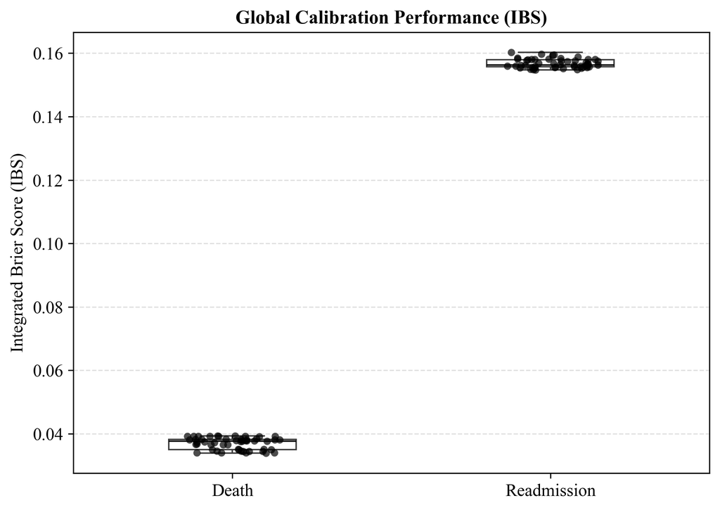

```python
#@title 📦 Global IBS Distribution by Outcome

import pandas as pd
import matplotlib.pyplot as plt
import seaborn as sns

# --- 1. LOAD DATA ---
# Assumes df_res exists OR you load it from CSV
# df_res = pd.read_csv("xgb6_death_final_summary_XXXX.csv")

ibs_df = df_res[
    (df_res['Metric'] == 'IBS') &
    (df_res['Time'] == 'Global')
].copy()

# --- 2. PLOT ---
plt.figure(figsize=(7, 5))

sns.boxplot(
    data=ibs_df,
    x='Risk',
    y='Value',
    width=0.4,
    showcaps=True,
    boxprops={'facecolor':'none'},
    medianprops={'color':'black'},
)

sns.stripplot(
    data=ibs_df,
    x='Risk',
    y='Value',
    color='black',
    alpha=0.7,
    jitter=0.15,
    size=5
)

plt.ylabel("Integrated Brier Score (IBS)")
plt.xlabel("")
plt.title("Global Calibration Performance (IBS)", fontsize=13, fontweight='bold')
plt.grid(axis='y', linestyle='--', alpha=0.4)

plt.tight_layout()
plt.show()
```

Mortality prediction shows consistently high specificity and near-perfect negative predictive value across follow-up, reflecting the low event incidence. Sensitivity declines gradually over time, while positive predictive value increases, indicating that deaths become easier to identify as long-term risk accumulates. Discrimination for death remains strong even at extended horizons.

In contrast, readmission is easier to predict shortly after discharge but becomes progressively harder over time. Sensitivity and discrimination decline, while specificity increases modestly. Although ruling out late readmission becomes less reliable, predicted late readmissions tend to be more credible. Overall, readmission displays greater temporal instability and heterogeneity than mortality.

Earlier AUC estimates were derived from a binary classification framing and are not directly comparable to the cause-specific, time-dependent AUC reported here.

## SHAP

Generates comprehensive analysis:

```
📂 Loading SHAP Data from: xgb6_death_final_SHAP_model_20260205_2134.pkl
   ✅ Model Type: <class 'xgboost.core.Booster'>
   ✅ Training Sample: (500, 56)
   ✅ Validation Sample: (100, 56)

⚡ Computing SHAP Values (TreeExplainer)...
   ✅ SHAP Values Shape: (100, 56)

📊 Generating Bar Plot...
   💾 Saved: XGB8_Death_Death_SHAP_Bar_20260205_2240.png
```

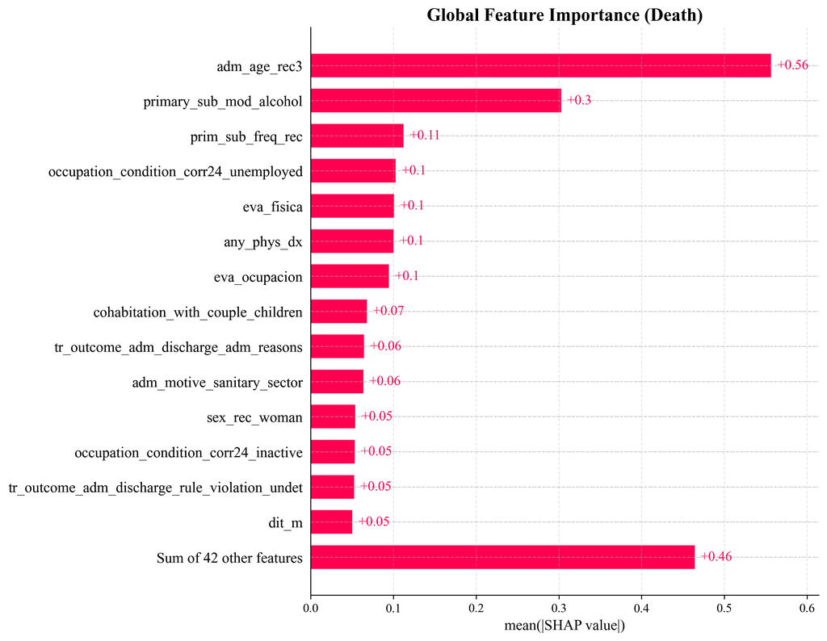

```
🐝 Generating Beeswarm Plot...
   💾 Saved: XGB8_Death_Death_SHAP_Beeswarm_20260205_2240.png
```

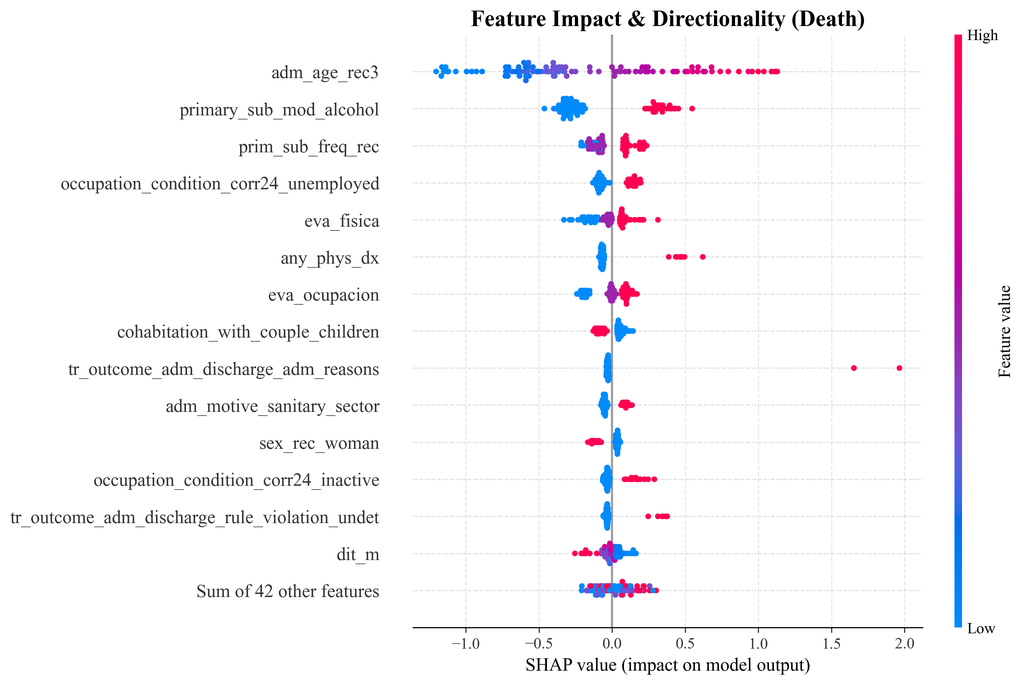

```
💧 Generating Waterfall Plots...
   💾 Saved: XGB8_Death_Death_SHAP_Waterfall_HighRisk_20260205_2240.png
```

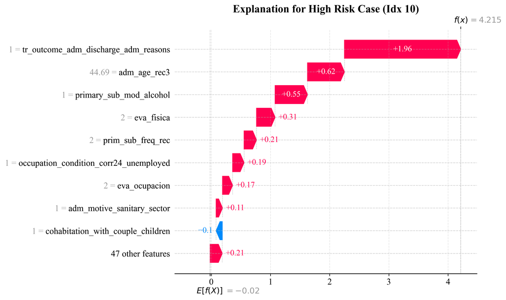

```
   💾 Saved: XGB8_Death_Death_SHAP_Waterfall_LowRisk_20260205_2240.png
```

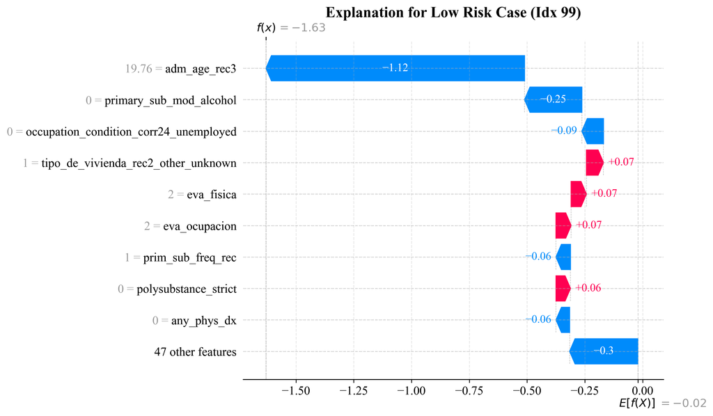

```
🏁 SHAP Analysis Complete.
```

```python
#@title 🔍 Step 8: SHAP Analysis & Plots (XGBoost Death)

import shap
import xgboost as xgb
import pickle
import numpy as np
import pandas as pd
import glob
import matplotlib.pyplot as plt
import matplotlib as mpl
from datetime import datetime

# --- 1. CONFIGURATION ---
# Font Settings: Times New Roman (Publication Ready)
mpl.rcParams.update({
    "font.family": "serif",
    "font.serif": ["Times New Roman", "Times", "Nimbus Roman", "DejaVu Serif"],
    "pdf.fonttype": 42,
    "ps.fonttype": 42,
    "axes.labelsize": 14,
    "axes.titlesize": 16,
    "xtick.labelsize": 12,
    "ytick.labelsize": 12,
    "figure.dpi": 300
})

timestamp = datetime.now().strftime("%Y%m%d_%H%M")

# --- 2. LOAD DATA ---
try:
    # Find the latest SHAP pickle file from Step 5
    shap_file = sorted(glob.glob("xgb6_death_final_SHAP_model_*.pkl"))[-1]
    print(f"📂 Loading SHAP Data from: {shap_file}")

    with open(shap_file, 'rb') as f:
        shap_data = pickle.load(f)

    # Extract Model & Data
    # Note: Step 5 saved the 'winner' which corresponds to the Death model
    model = shap_data['model_booster_d']  # This is a raw xgb.Booster

    # XGBoost shap needs pandas or numpy. We use the saved sample.
    X_train_sample = shap_data['X_train_sample']
    X_val_sample = shap_data['X_val_sample']
    feature_names = shap_data['feature_names']

    print(f"   ✅ Model Type: {type(model)}")
    print(f"   ✅ Training Sample: {X_train_sample.shape}")
    print(f"   ✅ Validation Sample: {X_val_sample.shape}")

except Exception as e:
    print(f"❌ Error loading data: {e}")
    raise

# --- 3. COMPUTE SHAP VALUES ---
print("\n⚡ Computing SHAP Values (TreeExplainer)...")

# TreeExplainer is optimized for XGBoost
explainer = shap.TreeExplainer(model)
shap_values = explainer(X_val_sample)

print(f"   ✅ SHAP Values Shape: {shap_values.shape}")

# --- 4. PLOTTING FUNCTION ---
def save_plot(fig, name):
    fname = f"XGB8_Death_Death_SHAP_{name}_{timestamp}"
    fig.savefig(f"{fname}.pdf", bbox_inches='tight')
    fig.savefig(f"{fname}.png", dpi=300, bbox_inches='tight')
    print(f"   💾 Saved: {fname}.png")

# --- 5. GENERATE PLOTS ---

# A. Global Bar Plot (Feature Importance)
print("\n📊 Generating Bar Plot...")
plt.figure(figsize=(10, 8))
shap.plots.bar(shap_values, max_display=15, show=False)
plt.title("Global Feature Importance (Death)", fontsize=16, fontweight='bold')
save_plot(plt.gcf(), "Bar")
plt.show()

# B. Beeswarm Plot (Directionality)
print("\n🐝 Generating Beeswarm Plot...")
plt.figure(figsize=(10, 8))
shap.plots.beeswarm(shap_values, max_display=15, show=False)
plt.title("Feature Impact & Directionality (Death)", fontsize=16, fontweight='bold')
save_plot(plt.gcf(), "Beeswarm")
plt.show()

# C. Waterfall Plots (Individual Explanations)
print("\n💧 Generating Waterfall Plots...")

# Case 1: High Risk Prediction (Find max output)
# XGBoost output is usually log-odds or risk score. Higher = Higher Risk.
max_idx = np.argmax(shap_values.values.sum(axis=1))
plt.figure(figsize=(10, 8))
shap.plots.waterfall(shap_values[max_idx], max_display=10, show=False)
plt.title(f"Explanation for High Risk Case (Idx {max_idx})", fontsize=16, fontweight='bold')
save_plot(plt.gcf(), "Waterfall_HighRisk")
plt.show()

# Case 2: Low Risk Prediction (Find min output)
min_idx = np.argmin(shap_values.values.sum(axis=1))
plt.figure(figsize=(10, 8))
shap.plots.waterfall(shap_values[min_idx], max_display=10, show=False)
plt.title(f"Explanation for Low Risk Case (Idx {min_idx})", fontsize=16, fontweight='bold')
save_plot(plt.gcf(), "Waterfall_LowRisk")
plt.show()

print("\n🏁 SHAP Analysis Complete.")
```

```
📂 Loading SHAP Data from: xgb6_death_final_SHAP_model_20260205_2134.pkl
✅ Found pre-trained Death model in pickle file.
   ✅ Model Type: <class 'xgboost.core.Booster'>
   ✅ Validation Sample: (100, 56)

⚡ Computing SHAP Values for Readmission (from death-focused pipeline)...
   ✅ SHAP Values Shape: (100, 56)

📊 Generating Bar Plot (Readmission)...
   💾 Saved: XGB8_Death_Readm_SHAP_Bar_20260205_2247.png
```

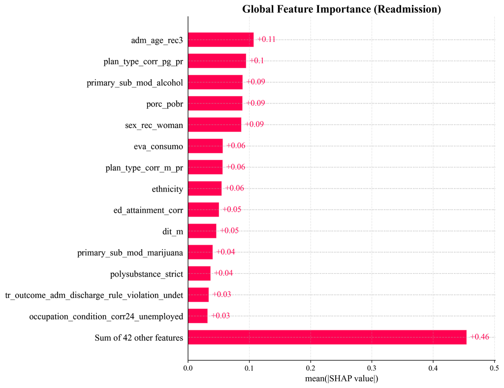

```
🐝 Generating Beeswarm Plot (Readmission)...
   💾 Saved: XGB8_Death_Readm_SHAP_Beeswarm_20260205_2247.png
```

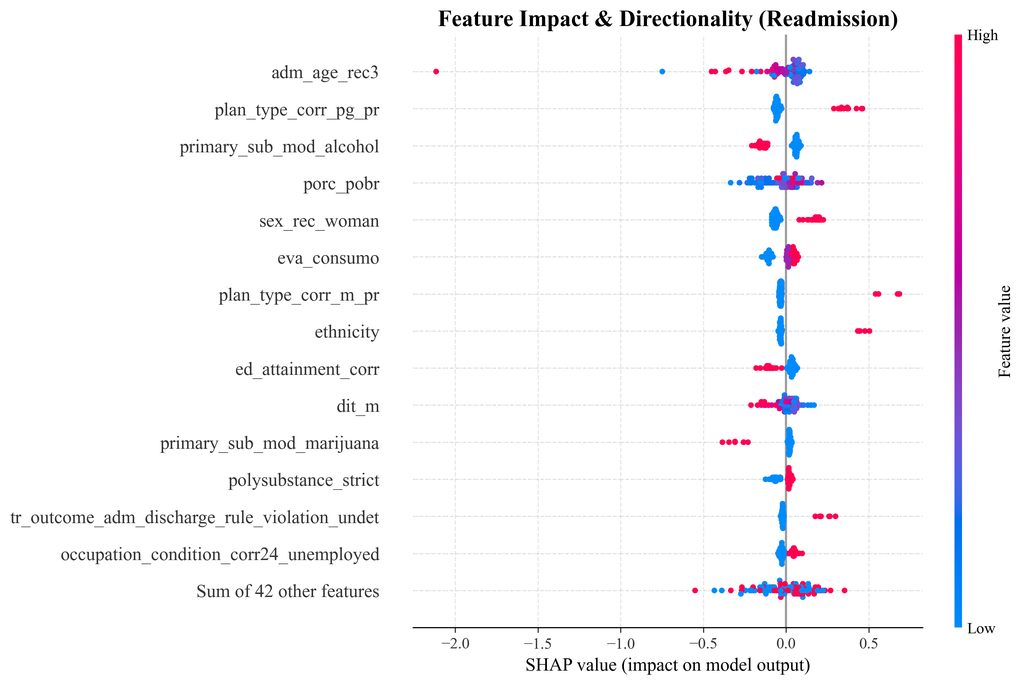

```
💧 Generating Waterfall Plots (Readmission)...
   💾 Saved: XGB8_Death_Readm_SHAP_Waterfall_HighRisk_20260205_2247.png
```

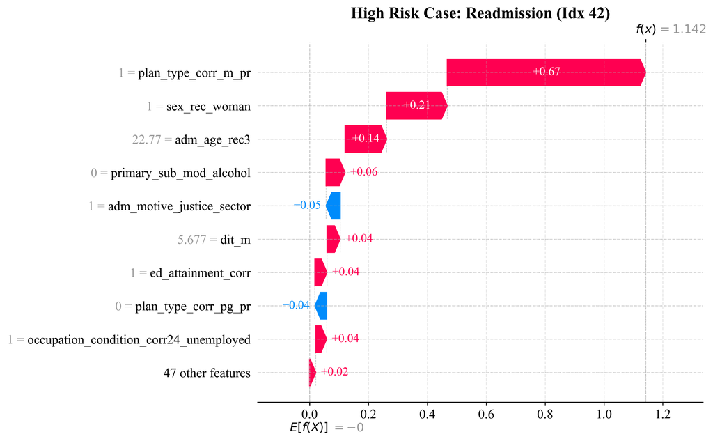

```
   💾 Saved: XGB8_Death_Readm_SHAP_Waterfall_LowRisk_20260205_2247.png
```

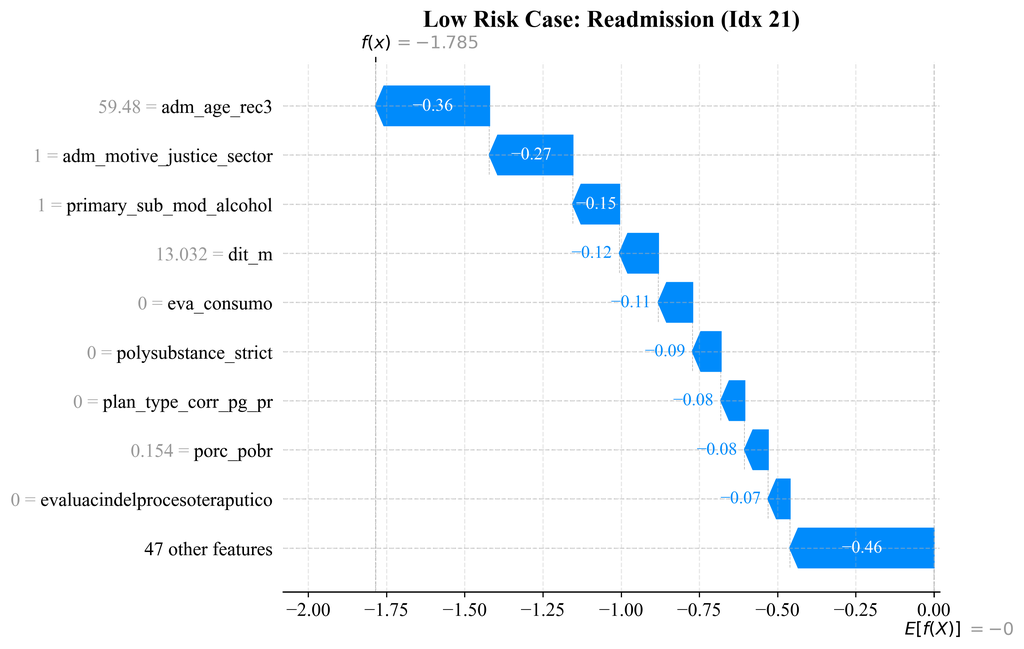

```
🏁 SHAP Analysis for Readmission Complete.
```

```python
#@title 🔍 Step 8: SHAP Analysis & Plots (XGBoost Readmission - Optimized)

import shap
import xgboost as xgb
import pickle
import numpy as np
import pandas as pd
import glob
import matplotlib.pyplot as plt
import matplotlib as mpl
from datetime import datetime

# --- 1. CONFIGURATION ---
mpl.rcParams.update({
    "font.family": "serif",
    "font.serif": ["Times New Roman", "Times", "Nimbus Roman", "DejaVu Serif"],
    "pdf.fonttype": 42,
    "ps.fonttype": 42,
    "axes.labelsize": 14,
    "axes.titlesize": 16,
    "xtick.labelsize": 12,
    "ytick.labelsize": 12,
    "figure.dpi": 300
})

timestamp = datetime.now().strftime("%Y%m%d_%H%M")

# --- 2. LOAD DATA ---
try:
    # Find the latest SHAP pickle file
    shap_file = sorted(glob.glob("xgb6_death_final_SHAP_model_*.pkl"))[-1]
    print(f"📂 Loading SHAP Data from: {shap_file}")

    with open(shap_file, 'rb') as f:
        shap_data = pickle.load(f)

    # --- KEY CHANGE: LOAD EXISTING DEATH MODEL ---
    if 'model_booster_r' in shap_data:
        print("✅ Found pre-trained Death model in pickle file.")
        model = shap_data['model_booster_r']
    else:
        raise KeyError(" 'model_booster_r' not found in file. Did you run the updated Step 5?")

    # Use the saved validation sample
    X_val_sample = shap_data['X_val_sample']
    feature_names = shap_data['feature_names']

    print(f"   ✅ Model Type: {type(model)}")
    print(f"   ✅ Validation Sample: {X_val_sample.shape}")

except Exception as e:
    print(f"❌ Error loading data: {e}")
    raise

# --- 3. COMPUTE SHAP VALUES ---
print("\n⚡ Computing SHAP Values for Readmission (from death-focused pipeline)...")

explainer = shap.TreeExplainer(model)
shap_values = explainer(X_val_sample)

print(f"   ✅ SHAP Values Shape: {shap_values.shape}")

# --- 4. PLOTTING FUNCTION ---
def save_plot(fig, name):
    fname = f"XGB8_Death_Readm_SHAP_{name}_{timestamp}"
    fig.savefig(f"{fname}.pdf", bbox_inches='tight')
    fig.savefig(f"{fname}.png", dpi=300, bbox_inches='tight')
    print(f"   💾 Saved: {fname}.png")

# --- 5. GENERATE PLOTS ---

# A. Global Bar Plot
print("\n📊 Generating Bar Plot (Readmission)...")
plt.figure(figsize=(10, 8))
shap.plots.bar(shap_values, max_display=15, show=False)
plt.title("Global Feature Importance (Readmission)", fontsize=16, fontweight='bold')
save_plot(plt.gcf(), "Bar")
plt.show()

# B. Beeswarm Plot
print("\n🐝 Generating Beeswarm Plot (Readmission)...")
plt.figure(figsize=(10, 8))
shap.plots.beeswarm(shap_values, max_display=15, show=False)
plt.title("Feature Impact & Directionality (Readmission)", fontsize=16, fontweight='bold')
save_plot(plt.gcf(), "Beeswarm")
plt.show()

# C. Waterfall Plots
print("\n💧 Generating Waterfall Plots (Readmission)...")

# Case 1: High Risk
max_idx = np.argmax(shap_values.values.sum(axis=1))
plt.figure(figsize=(10, 8))
shap.plots.waterfall(shap_values[max_idx], max_display=10, show=False)
plt.title(f"High Risk Case: Readmission (Idx {max_idx})", fontsize=16, fontweight='bold')
save_plot(plt.gcf(), "Waterfall_HighRisk")
plt.show()

# Case 2: Low Risk
min_idx = np.argmin(shap_values.values.sum(axis=1))
plt.figure(figsize=(10, 8))
shap.plots.waterfall(shap_values[min_idx], max_display=10, show=False)
plt.title(f"Low Risk Case: Readmission (Idx {min_idx})", fontsize=16, fontweight='bold')
save_plot(plt.gcf(), "Waterfall_LowRisk")
plt.show()

print("\n🏁 SHAP Analysis for Readmission Complete.")
```

```python
#@title 📊 Step 9: Export Detailed Predictor Analysis (XGBoost - Local)

import pandas as pd
import numpy as np
import shap
import xgboost as xgb
import pickle
import glob
from scipy.stats import pearsonr
from datetime import datetime
import matplotlib.pyplot as plt
from sklearn.model_selection import StratifiedKFold

# --- 1. CONFIGURATION ---
timestamp = datetime.now().strftime("%Y%m%d_%H%M")
excel_filename = f"XGB9_Death_Predictor_Analysis_{timestamp}.xlsx"

# --- 2. HELPER FUNCTIONS ---

def get_direction_and_robustness(feature_values, shap_values):
    """
    Determines if a feature is a Risk Factor vs Protective based on correlation.
    """
    # 1. Robustness: Std Dev of the absolute impact
    robustness = np.std(np.abs(shap_values))

    # 2. Direction: Correlation between Feature Value and SHAP Value
    try:
        # Handle constant features
        if np.std(feature_values) < 1e-6:
            return "Neutral (Constant)", 0.0, 0.0

        corr, _ = pearsonr(feature_values, shap_values)

        if corr > 0.1: direction = "Risk Factor (↑)"
        elif corr < -0.1: direction = "Protective (↓)"
        else: direction = "Mixed/Non-Linear"

        return direction, corr, robustness
    except:
        return "Unknown", 0.0, robustness

def analyze_risk_factors_xgb(model, X_data, feature_names, risk_name):
    """
    Generates the top 25 predictor table for a given XGBoost model.
    """
    print(f"⚡ Analyzing top 25 predictors for: {risk_name}...")

    # A. Get SHAP Values (TreeExplainer is fast for XGBoost)
    explainer = shap.TreeExplainer(model)
    shap_vals_obj = explainer(X_data)

    # Handle different SHAP versions (some return object, some array)
    if hasattr(shap_vals_obj, "values"):
        shap_vals = shap_vals_obj.values
    else:
        shap_vals = shap_vals_obj # Fallback for older versions

    # B. Compile Metrics
    feature_data = []

    for i, fname in enumerate(feature_names):
        # Extract columns
        if isinstance(X_data, pd.DataFrame):
            f_values = X_data.iloc[:, i].values
        else:
            f_values = X_data[:, i]

        s_values = shap_vals[:, i]

        # 1. Global Importance (Mean |SHAP|)
        importance = np.mean(np.abs(s_values))

        # 2. Direction & Robustness
        direction, corr, robust_score = get_direction_and_robustness(f_values, s_values)

        feature_data.append({
            'Rank': 0, # Placeholder
            'Feature': fname,
            'Importance (Mean |SHAP|)': importance,
            'Direction': direction,
            'Type': 'Risk' if 'Risk' in direction else 'Protective' if 'Protective' in direction else 'Complex',
            'Robustness (SD of Impact)': robust_score,
            'Correlation (Value vs Risk)': corr
        })

    # C. Create DataFrame & Sort
    df = pd.DataFrame(feature_data)
    df = df.sort_values(by='Importance (Mean |SHAP|)', ascending=False).reset_index(drop=True)
    df['Rank'] = df.index + 1

    return df.head(25)

# --- 3. MAIN EXECUTION ---

try:
    # ---------------------------------------------------------
    # A. LOAD READMISSION MODEL (From Step 6/5 Pickle)
    # ---------------------------------------------------------
    print("\n📂 Loading Readmission Model...")
    # Matches: xgb6_readm_SHAP_model_*.pkl
    readm_pkl_candidates = sorted(glob.glob("xgb6_death_final_SHAP_model_*.pkl"))
    if not readm_pkl_candidates:
        raise FileNotFoundError("Could not find 'xgb6_death_final_SHAP_model_*.pkl'. Did Step 5 run?")

    readm_pkl = readm_pkl_candidates[-1]
    print(f"   Using: {readm_pkl}")

    with open(readm_pkl, 'rb') as f:
        readm_data = pickle.load(f)

    # Check if we have the new dual-model structure or the old single-model one
    if 'model_booster_r' in readm_data:
        print("   ✅ Detected dual-model pickle format.")
        model_r = readm_data['model_booster_r']
    else:
        print("   ⚠️ Detected legacy single-model pickle format.")
        model_r = readm_data['model_booster'] # Fallback for old file

    X_val_r = readm_data['X_val_sample']
    feats_r = readm_data['feature_names']

    # Generate Table
    df_readm = analyze_risk_factors_xgb(model_r, X_val_r, feats_r, "Readmission")

    # ---------------------------------------------------------
    # B. LOAD OR RE-TRAIN DEATH MODEL
    # ---------------------------------------------------------
    print("\n🔄 Preparing Death Model Analysis...")

    # Check if Death model is already in the pickle (New file version)
    if 'model_booster_d' in readm_data:
        print("   ✅ Found pre-trained Death model in pickle. Using it.")
        model_d = readm_data['model_booster_d']
        X_val_d = X_val_r # Use same validation set
    else:
        # Re-train only if necessary (Old file version)
        print("   ⚠️ Death model not in pickle. Re-training from raw data...")

        # 1. Load Summary to find the best fold
        summary_csv_candidates = sorted(glob.glob("xgb6_readm_final_summary_*.csv"))
        if not summary_csv_candidates:
            raise FileNotFoundError("Could not find 'xgb6_readm_final_summary_*.csv'.")

        summary_csv = summary_csv_candidates[-1]
        df_res = pd.read_csv(summary_csv)
        df_r_metrics = df_res[df_res['Risk'] == 'Readmission']
        fold_scores = df_r_metrics[df_r_metrics['Metric'] == "Uno's C-Index"].groupby(['Imp', 'Fold'])['Value'].mean()
        global_median = fold_scores.median()
        best_idx = (fold_scores - global_median).abs().idxmin()
        target_imp, target_fold = best_idx

        print(f"   Target: Imp {target_imp}, Fold {target_fold}")

        # 2. Load Raw Data
        if 'imputations_list_jan26' not in locals():
            raise NameError("Global data 'imputations_list_jan26' not found. Please load data first.")

        # Data Prep
        X_raw = imputations_list_jan26[target_imp]
        X_curr = pd.get_dummies(X_raw, drop_first=True).astype('float32')
        y_d = y_surv_death_list[target_imp]

        # Stratification
        e_d_full = y_d['event'] if isinstance(y_d['event'], np.ndarray) else y_d['event'].values.astype(bool)
        plan_labels = np.zeros(len(X_curr), dtype=int)
        if 'plan_type_corr_pg_pr' in X_curr.columns: plan_labels[X_curr['plan_type_corr_pg_pr'] == 1] = 1
        strat_labels = (e_d_full.astype(int) * 10) + plan_labels

        # Split
        skf = StratifiedKFold(n_splits=10, shuffle=True, random_state=2125)
        splits = list(skf.split(X_curr, strat_labels))
        train_idx, val_idx = splits[target_fold]

        X_tr, X_va = X_curr.iloc[train_idx], X_curr.iloc[val_idx]
        y_d_tr = y_d[train_idx]

        # Labels for Cox
        y_xgb_tr = np.where(y_d_tr['event'], y_d_tr['time'], -y_d_tr['time'])
        dtrain = xgb.DMatrix(X_tr, label=y_xgb_tr)

        # Train
        params = {
            'objective': 'survival:cox', 'tree_method': 'hist', 'learning_rate': 0.02,
            'max_depth': 6, 'min_child_weight': 20, 'reg_alpha': 0.1, 'reg_lambda': 5.0,
            'subsample': 0.8, 'colsample_bytree': 0.7, 'nthread': 29, 'verbosity': 0
        }
        model_d = xgb.train(params, dtrain, num_boost_round=1000)
        X_val_d = X_va # Use reconstructed validation set

    # Generate Table
    df_death = analyze_risk_factors_xgb(model_d, X_val_d, feats_r, "Death")

    # ---------------------------------------------------------
    # C. EXPORT TO EXCEL
    # ---------------------------------------------------------
    print(f"\n💾 Saving to Excel: {excel_filename}...")

    with pd.ExcelWriter(excel_filename, engine='xlsxwriter') as writer:
        # Sheet 1: Death
        df_death.to_excel(writer, sheet_name='Death Predictors', index=False)

        # Sheet 2: Readmission
        df_readm.to_excel(writer, sheet_name='Readm Predictors', index=False)

        # Sheet 3: Definitions
        meta_data = pd.DataFrame([
            {'Metric': 'Importance', 'Definition': 'Mean absolute SHAP value. Represents the average magnitude of impact on the model output (Log-Risk).'},
            {'Metric': 'Direction', 'Definition': 'Determined by correlation. "Risk Factor" means higher values increase risk. "Protective" means higher values decrease risk.'},
            {'Metric': 'Robustness (SD)', 'Definition': 'Standard Deviation of the |SHAP| values. Low SD = Consistent impact across all patients. High SD = Impact depends heavily on context (interactions).'},
            {'Metric': 'Correlation', 'Definition': 'Pearson correlation between the raw feature value and its SHAP value.'}
        ])
        meta_data.to_excel(writer, sheet_name='Definitions', index=False)

        # Formatting
        for sheet in ['Death Predictors', 'Readm Predictors', 'Definitions']:
            worksheet = writer.sheets[sheet]
            worksheet.set_column('B:B', 30) # Feature Name Width
            worksheet.set_column('C:G', 15) # Metric Widths

    print(f"✅ Export complete: {excel_filename}")

except Exception as e:
    print(f"❌ Unexpected Error: {e}")
    # Print Traceback for debugging
    import traceback
    traceback.print_exc()
```

```
📂 Loading Readmission Model...
   Using: xgb6_death_final_SHAP_model_20260205_2134.pkl
   ✅ Detected dual-model pickle format.
⚡ Analyzing top 25 predictors for: Readmission...

🔄 Preparing Death Model Analysis...
   ✅ Found pre-trained Death model in pickle. Using it.
⚡ Analyzing top 25 predictors for: Death...

💾 Saving to Excel: XGB9_Death_Predictor_Analysis_20260205_2251.xlsx...
✅ Export complete: XGB9_Death_Predictor_Analysis_20260205_2251.xlsx
```

```python
take_home_msg = pd.DataFrame([
    {
        'Risk Profile': 'Death (Clinical–Biological Decline)',
        'Top Predictors': (
            'Older age, Alcohol use disorder, Higher use frequency, '
            'Unemployment, Physical morbidity'
        ),
        'Interpretation': (
            'Mortality risk is dominated by biological aging and substance-related clinical severity. '
            'Older individuals with severe alcohol involvement, frequent use, physical comorbidities, '
            'and labor-market exclusion show the highest risk. Social integration and treatment retention '
            'act as consistent protective factors.'
        )
    },
    {
        'Risk Profile': 'Readmission (Social & Programmatic Instability)',
        'Top Predictors': (
            'Program type, Poverty, Female sex, Younger age, Ethnicity'
        ),
        'Interpretation': (
            'Readmission risk reflects social vulnerability and system-level dynamics rather than clinical decline. '
            'Program assignment, socioeconomic disadvantage, and demographic factors dominate, while clinical severity '
            'plays a secondary and sometimes protective role.'
        )
    }
])
pd.set_option('display.max_colwidth', None)

display(take_home_msg)
```

[output not shown]